# Food consumption and cancer

Steffe Colin

06 septembre, 2022

# **1 Introduction**

## 1.1 Overview and motivation

Nowadays, cancer has become the second leading cause of death in the world, a disease that can affect anyone directly or indirectly, through family members or close friends.  
Both having either already lost a loved one very quickly and suddenly to the advanced stage of cancer disease or learned that one of them was diagnosed with cancer. We therefore feel intrigued by this disease which remains until today a mystery in terms of medical care, treatment and recommendations to stabilize and ideally reduce the growth of cancer cells in the body.  
No one is spared and it can affect people with a very healthy lifestyle just as much as others who do not necessarily care about their health. This is why we have noted with our different experiences and various conversations on the subject that professionals in the field do not necessarily have the same recommendations in terms of food advice and diets, or even contradictory in certain situations.

So, we decided to look at the relationship between - diet and cancer. Knowing that the increase of the disease in the human body is due to several factors including bad eating habits, we ask ourselves the question: what are really these bad eating habits? is meat one of them? Some diets encourage people to eat more meat, such as the super protein diet while other diets strongly discourage meat consumption. Yet in 2015, WHO had classified red meat as a carcinogen.

So, our objectives are to see if there is any relation between the different foods, that is to say vegetables, fruits, meats and cancer. We will also take into account all other variables that are not related to diet such as smoking cigarettes, age, gender, physical activity, alcohol consumption and the economic status of our respondents. Ideally, we would like to bring a more scientific and informative approach to the topic as there is a lot of confusion on this topic due to the wide availability information on the Internet and trends in different regimes.

## 1.2 Research questions

1. Does eating meat have a relationship with cancer ?  
   Our hypothesis is that meat consumption may increase the risk of cancer.
2. Does eating dairy products have a relationship with cancer ?  
   Our hypothesis is that dairy products consumption may increase the risk of cancer.
3. Does eating vegetable have a relationship with cancer ?  
   Our hypothesis is that vegetable consumption may decrease the risk of cancer.
4. Does eating fruit have a relationship with cancer ?  
   Our hypothesis is that fruit consumption may decrease the risk of cancer.
5. Does having an healthy has a effect on cancer ?  
   Our hypothesis is that having a healthy diet may decrease the risk of cancer.

At the beginning we wanted to mainly focus on meat, but finally we have decided to broaden our scope. Moreover these questions might evolve once we will be working on the analysis part.

## 1.3 Related work

WHO report says eating processed meat and red meat are carcinogenic : https://www.hsph.harvard.edu/nutritionsource/2015/11/03/report-says-eating-processed-meat-is-carcinogenic-understanding-the-findings/

Health Concerns About Dairy. From Washington Physician committee responsible medecine:  
https://www.pcrm.org/good-nutrition/nutrition-information/health-concerns-about-dairy#:~:text=Milk%20and%20other%20dairy%20products,%2C%20ovarian%2C%20and%20prostate%20cancers.

Does having a healthy diet reduce my risk of cancer? From Cancer research UK:  
https://www.cancerresearchuk.org/about-cancer/causes-of-cancer/diet-and-cancer/does-having-a-healthy-diet-reduce-my-risk-of-cancer

Diet and Physical Activity: What’s the Cancer Connection? From American Cancer Society:  
https://www.cancer.org/cancer/cancer-causes/diet-physical-activity/diet-and-physical-activity.html

# **2 Data**

## 2.1 Sources

Our data comes from the National Health and Nutrition Examination Survey (https://www.cdc.gov/nchs/nhanes/). Each year this institution asks a large amount of questions to a wide representative panel of respondents. Those questions are related to demographic, social economics, health and nutrition. We chose the year 2005 because it is the year that has the richest nutritional database in terms of variety and it is also the one that we found the most relevant and the most qualitative compared to other years. There is a very strong relationship between all our datasets as the survey participants are labeled. Therefore, many of them responded to every surveys.

For our study we will use 7 datasets :

- Nutrition dataset -> https://wwwn.cdc.gov/Nchs/Nhanes/2005-2006/FFQRAW_D.htm
- Diet Behavior & Nutrition dataset -> https://wwwn.cdc.gov/Nchs/Nhanes/2005-2006/DBQ_D.htm#DBQ700
- Medical condition dataset -> https://wwwn.cdc.gov/Nchs/Nhanes/2005-2006/MCQ_D.htm#MCQ220
- alcohol dataset -> https://wwwn.cdc.gov/Nchs/Nhanes/2005-2006/ALQ_D.htm
- Demography dataset -> https://wwwn.cdc.gov/Nchs/Nhanes/2005-2006/DEMO_D.htm
- Physical activity dataset ->https://wwwn.cdc.gov/Nchs/Nhanes/2005-2006/PAQ_D.htm
- Smoking - Cigarette Use dataset -> https://wwwn.cdc.gov/Nchs/Nhanes/2005-2006/SMQ_D.htm

## 2.2 Data description

### 2.2.1 Nutrition dataset

Here is a preview of our first dataset.

```
#> Rows: 6,013
#> Columns: 15
#> $ SEQN     <dbl> 31129, 31131, 31132, 31133, 31134, 31139, 31141, 3~
#> $ WTS_FFQ  <dbl> 36621, 21244, 50102, 6008, 47303, 4176, 5791, 6768~
#> $ DRDINT   <dbl> 2, 2, 2, 2, 2, 2, 2, 2, 2, 2, 2, 2, 2, 2, 2, 2, 2,~
#> $ FFQ_MISS <dbl> 1, 0, 1, 1, 0, 1, 0, 1, 0, 0, 3, 0, 0, 5, 1, 1, 0,~
#> $ FFQ0001  <dbl> 1, 1, 1, 1, 4, 1, 2, 1, 1, 3, 1, 1, 2, 2, 3, 5, 3,~
#> $ FFQ0002  <dbl> 5, 2, 1, 3, 4, 1, 1, 3, 4, 5, 3, 5, 2, 8, 2, 8, 3,~
#> $ FFQ0003  <dbl> 5, 7, 1, 4, 2, 1, 3, 3, 1, 5, 5, 5, 1, 1, 2, 6, 1,~
#> $ FFQ0004  <dbl> 5, 2, 1, 5, 1, 1, 3, 3, 2, 4, 4, 4, 1, 1, 2, 3, 1,~
#> $ FFQ0005  <dbl> 6, 2, 1, 1, 2, 1, 3, 2, 1, 4, 5, 8, 1, 2, 2, 6, 1,~
#> $ FFQ0006  <dbl> 8, 8, 1, 2, 3, 7, 5, 7, 3, 8, 3, 6, 1, 1, 1, 88, 1~
#> $ FFQ0006A <dbl> 1, 1, 88, 1, 3, 5, 1, 2, 88, 1, 1, 1, 88, 88, 88, ~
#> $ FFQ0007  <dbl> 6, 1, 1, 88, 2, 7, 9, 8, 2, 8, 6, 3, 2, 1, 6, 2, 1~
#> $ FFQ0007A <dbl> 1, 88, 88, 2, 3, 1, 4, 2, 4, 1, 1, 1, 1, 88, 1, 5,~
#> $ FFQ0008  <dbl> 1, 1, 1, 3, 1, 1, 1, 3, 2, 1, 1, 1, 1, 1, 1, 8, 1,~
#> $ FFQ0009  <dbl> 1, 1, 2, 1, 1, 2, 1, 1, 88, 1, 2, 1, 1, 2, 2, 1, 1~
```

This first dataset about nutrition has 6013 observations and 225 variables, it is important to highlight that most of our variables are categorical numeric variables ranged from 1 to 11 :  
-1 = never  
-2 = 1-6 times per year  
-3 = 7-11 times per year  
-4 = 1 time per month  
-5 = 2-3 times per month  
-6 = 1 time per week  
-7 = 2 times per week  
-8 = 3-4 times per week  
-9 = 5-6 times per week  
-10 = 1 time per day  
-11 = 2 or more times per day  
Other values are either blank or error and will be transformed to NA during cleaning process.

In this dataset we will use many variables that are of interest for our analysis, including :  
-`SEQN` - Respondent Sequence Number, it will be our reference to merge our different datasets.

-`FFQ0069` - Q.69 Roast beef sandwiches eaten?  
-`FFQ0070` - Q.70 Did you eat cold cuts?  
-`FFQ0071` - Q.71 Did you eat luncheon ham?  
-`FFQ0072` - Q.72 Did you eat other cold cuts?  
-`FFQ0074` - Q.74 Did you eat GROUND chicken?  
-`FFQ0075` - Q.75 Did you eat beef hamburgers?  
-`FFQ0076` - Q.76 Ground beef mixtures eaten?  
-`FFQ0077` - Q.77 Did you eat hot dogs?  
-`FFQ0078` - Q.78 Other beef mixtures eaten?  
-`FFQ0079` - Q.79 Roast beef eaten at other times?  
-`FFQ0080` - Q.80 Did you eat steak?  
-`FFQ0081` - Q.81 Did you eat spareribs?  
-`FFQ0082` - Q.82 Did you eat roast turkey?  
-`FFQ0083` - Q.83 Did you eat chicken in mixtures?  
-`FFQ0084` - Q.84 Did you eat baked chicken?  
-`FFQ0085` - Q.85 Did you eat baked ham?  
-`FFQ0086` - Q.86 Did you eat pork?  
-`FFQ0088` - Q.88 Did you eat liver?  
-`FFQ0089` - Q.89 Did you eat bacon?  
-`FFQ0090` - Q.90 Did you eat sausage?

-`FFQ0007` - Q.7 How often drink milk as a beverage?  
-`FFQ0108` - Q.108 Did you eat yogurt?  
-`FFQ0109` - Q.109 Did you eat cottage cheese?  
-`FFQ0110` - Q.110 Did you eat cheese?  
-`FFQ0111` - Q.111 Did you eat frozen yogurt?  
-`FFQ0112` - Q.112 Did you eat ice cream?  
-`FFQ0137` - Q.137 Did you eat cream cheese?  
-`FFQ0138` - Q.138 Did you eat sour cream?

-`FFQ0028` - Q.28 Did you eat cooked greens? (such as spinach, turnip, collard, mustard, chard, or kale)  
-`FFQ0029` - Q.29 Did you eat raw greens? (such as spinach, turnip, collard, mustard, chard, or kale)  
-`FFQ0030` - Q.30 Did you eat coleslaw?  
-`FFQ0031` - Q.31 Did you eat sauerkraut?  
-`FFQ0032` - Q.32 Did you eat carrots?  
-`FFQ0033` - Q.33 Did you eat string beans?  
-`FFQ0034` - Q.34 Did you eat peas?  
-`FFQ0035` - Q.35 Did you eat corn?  
-`FFQ0036` - Q.36 Did you eat broccoli?  
-`FFQ0037` - Q.37 Did you eat cauliflower?  
-`FFQ0038` - Q.38 Did you eat mixed veggies?  
-`FFQ0039` - Q.39 Did you eat onions?  
-`FFQ0040` - Q.40 Did you eat peppers?  
-`FFQ0041` - Q.41 Did you eat cucumbers?  
-`FFQ0042` - Q.42 Fresh tomatoes eaten?  
-`FFQ0043` - Q.43 Did you eat summer squash?  
-`FFQ0044` - Q.44 Did you eat lettuce salads?

-`FFQ0015` - Q.15 Did you eat applesauce?  
-`FFQ0016` - Q.16 Did you eat apples?  
-`FFQ0017` - Q.17 Did you eat pears?  
-`FFQ0018` - Q.18 Did you eat bananas?  
-`FFQ0019` - Q.19 Did you eat pineapple?  
-`FFQ0020` - Q.20 Did you eat dried fruit?  
-`FFQ0021` - Q.21 Did you eat peaches?  
-`FFQ0022` - Q.22 Did you eat grapes?  
-`FFQ0023` - Q.23 Did you eat melons?  
-`FFQ0024` - Q.24 Fresh strawberries eaten?  
-`FFQ0025` - Q.25 Did you eat oranges?  
-`FFQ0026` - Q.26 Did you eat grapefruit?  
-`FFQ0027` - Q.27 Did you eat other kinds of fruit?

Here we can observe the proportion of missing values for the selected variables.

|  | missing | % |
| --- | --- | --- |
| SEQN | 0 | 0 |
| FFQ0069 | 0 | 0 |
| FFQ0070 | 0 | 0 |
| FFQ0071 | 0 | 0 |
| FFQ0072 | 0 | 0 |
| FFQ0074 | 0 | 0 |
| FFQ0075 | 0 | 0 |
| FFQ0076 | 0 | 0 |
| FFQ0077 | 0 | 0 |
| FFQ0078 | 0 | 0 |
| FFQ0079 | 0 | 0 |
| FFQ0080 | 0 | 0 |
| FFQ0081 | 0 | 0 |
| FFQ0082 | 0 | 0 |
| FFQ0083 | 0 | 0 |

There is no NA in this dataset.

### 2.2.2 Diet Behavior & Nutrition dataset

Here is a preview of our second dataset.

```
#> Rows: 10,348
#> Columns: 15
#> $ SEQN    <dbl> 31127, 31128, 31129, 31130, 31131, 31132, 31133, 31~
#> $ DBQ010  <dbl> 1, NA, NA, NA, NA, NA, NA, NA, 1, NA, NA, 1, NA, NA~
#> $ DBD020  <dbl> 121, NA, NA, NA, NA, NA, NA, NA, 152, NA, NA, 91, N~
#> $ DBD030  <dbl> 121, NA, NA, NA, NA, NA, NA, NA, 182, NA, NA, 152, ~
#> $ DBD040  <dbl> 121, NA, NA, NA, NA, NA, NA, NA, 152, NA, NA, 91, N~
#> $ DBD050  <dbl> 304, NA, NA, NA, NA, NA, NA, NA, 0, NA, NA, 365, NA~
#> $ DBD060  <dbl> 304, NA, NA, NA, NA, NA, NA, NA, 0, NA, NA, 365, NA~
#> $ DBD072A <dbl> 10, NA, NA, NA, NA, NA, NA, NA, NA, NA, NA, 10, NA,~
#> $ DBD072B <dbl> NA, NA, NA, NA, NA, NA, NA, NA, NA, NA, NA, NA, NA,~
#> $ DBD072C <dbl> NA, NA, NA, NA, NA, NA, NA, NA, NA, NA, NA, NA, NA,~
#> $ DBD072D <dbl> NA, NA, NA, NA, NA, NA, NA, NA, NA, NA, NA, NA, NA,~
#> $ DBD072U <dbl> NA, NA, NA, NA, NA, NA, NA, NA, NA, NA, NA, NA, NA,~
#> $ DBD080  <dbl> 212, NA, NA, NA, NA, NA, NA, NA, 182, NA, NA, 273, ~
#> $ DBQ700  <dbl> NA, NA, NA, 3, 3, 2, 5, 3, NA, 3, NA, NA, 3, NA, 3,~
#> $ DBQ197  <dbl> NA, 3, 3, 3, 1, 3, 0, 2, NA, 0, 3, 3, 3, 3, 3, 3, 3~
```

This second dataset has 10348 observations and 53 variables. for our analysis we are only going to use two variables :  
-`SEQN` - Respondent sequence number. It will be our reference to merge our different datasets.

-`DBQ700` - How healthy is the diet, this variable take a values : 1= Excellent, 2=Very good, 3=Good, 4= fair, 5= poor. all other values are either “refused” or “don’t know” and will be cleaned.

Here we can observe the proportion of missing values for the selected variables.

```
#>        missing  %
#> DBQ700    4209 41
#> SEQN         0  0
```

### 2.2.3 Medical dataset

Here is a preview of our third dataset.

```
#> Rows: 9,822
#> Columns: 15
#> $ SEQN    <dbl> 31128, 31129, 31130, 31131, 31132, 31133, 31134, 31~
#> $ MCQ010  <dbl> 2, 2, 2, 2, 2, 2, 2, 2, 2, 2, 1, 2, 2, 2, 2, 2, 2, ~
#> $ MCQ025  <dbl> NA, NA, NA, NA, NA, NA, NA, NA, NA, NA, 1, NA, NA, ~
#> $ MCQ035  <dbl> NA, NA, NA, NA, NA, NA, NA, NA, NA, NA, 2, NA, NA, ~
#> $ MCQ040  <dbl> NA, NA, NA, NA, NA, NA, NA, NA, NA, NA, NA, NA, NA,~
#> $ MCQ050  <dbl> NA, NA, NA, NA, NA, NA, NA, NA, NA, NA, NA, NA, NA,~
#> $ MCQ053  <dbl> 2, 2, 2, 2, 2, 2, 2, 2, 2, 2, 2, 2, 2, 2, 2, 2, 2, ~
#> $ MCQ080  <dbl> NA, NA, 2, 2, 2, 2, 1, 1, NA, NA, 1, NA, 2, NA, 2, ~
#> $ MCQ092  <dbl> 2, 2, 9, 1, 2, 2, 2, 2, 2, NA, 2, 2, 2, 2, 2, 2, 2,~
#> $ MCD093  <dbl> NA, NA, NA, 3, NA, NA, NA, NA, NA, NA, NA, NA, NA, ~
#> $ MCQ140  <dbl> 2, 2, 2, 2, 2, 2, 2, 2, 2, 2, 2, 2, 2, 1, 2, 2, 2, ~
#> $ MCQ149  <dbl> 2, NA, NA, NA, NA, NA, NA, NA, NA, NA, NA, 2, NA, N~
#> $ MCQ150G <dbl> 1, 1, NA, NA, NA, 1, NA, NA, 1, NA, 2, 1, 1, 1, 1, ~
#> $ MCQ150Q <dbl> 2, 1, NA, NA, NA, 12, NA, NA, 3, NA, NA, 3, 0, 8, 2~
#> $ MCQ160A <dbl> NA, NA, 2, 2, 2, NA, 2, 2, NA, NA, NA, NA, NA, NA, ~
```

This third dataset is about medical condition has 9822 observations and 89 variables. For our analysis we are going to use :  
-`SEQN` - Respondent sequence number, which will be our reference to merge our different datasets.

-`MCQ220` - Ever told you had cancer or malignancy ? This variable is the one that we will use the most in our analysis.  
-`MCQ230A` - What kind of cancer  
-`MCQ230B` - What kind of cancer  
-`MCQ230C` - What kind of cancer  
The variable : what kind of cancer exists 4 times(A,B,C,D) in case respondents had multiple cancers, but we will not use the 4th as nobody ever got a 4th cancer.

Here we can observe the proportion of missing values for the selected variables.

```
#>         missing   %
#> MCQ230C    9818 100
#> MCQ230B    9778 100
#> MCQ230A    9413  96
#> MCQ220     4847  49
#> SEQN          0   0
```

Only half of the respondents answered if they had cancer or not, and only 4% provided the type of cancer they got.

### 2.2.4 Alcohol dataset

Here is a preview of our forth dataset.

```
#> Rows: 4,773
#> Columns: 9
#> $ SEQN    <dbl> 31130, 31131, 31132, 31134, 31144, 31149, 31150, 31~
#> $ ALQ101  <dbl> NA, 2, 1, 1, 1, 2, 1, 2, 2, 1, 1, 2, NA, 1, 1, 2, 2~
#> $ ALQ110  <dbl> NA, 1, NA, NA, NA, 2, NA, 1, 2, NA, NA, 2, NA, NA, ~
#> $ ALQ120Q <dbl> NA, 0, 4, 2, 2, NA, 7, 0, NA, 0, 3, NA, NA, 4, 3, 0~
#> $ ALQ120U <dbl> NA, NA, 1, 1, 2, NA, 1, NA, NA, NA, 1, NA, NA, 1, 2~
#> $ ALQ130  <dbl> NA, NA, 1, 2, 2, NA, 3, NA, NA, NA, 3, NA, NA, 2, 1~
#> $ ALQ140Q <dbl> NA, NA, 0, 0, 0, NA, 0, NA, NA, NA, 2, NA, NA, 40, ~
#> $ ALQ140U <dbl> NA, NA, NA, NA, NA, NA, NA, NA, NA, NA, 3, NA, NA, ~
#> $ ALQ150  <dbl> NA, 2, 2, 2, 2, NA, 1, 2, NA, 1, 2, NA, NA, 2, 2, 2~
```

This 4th dataset is about Alcohol consumption, it has 4773observations and 9 variables. For our analysis we are going to use :  
-`SEQN` - Respondent sequence number, it will be our reference to merge our different datasets.

-`ALQ130` - Avg # alcoholic drinks/day -past 12 mos

Here we can observe the proportion of missing values for the selected variables.

```
#>        missing  %
#> ALQ130    1953 41
#> SEQN         0  0
```

There is 41% of missing values about alcohol consumption.

### 2.2.5 Demography dataset

Here is a preview of our fifth dataset.

```
#> Rows: 10,348
#> Columns: 15
#> $ SEQN     <dbl> 31127, 31128, 31129, 31130, 31131, 31132, 31133, 3~
#> $ SDDSRVYR <dbl> 4, 4, 4, 4, 4, 4, 4, 4, 4, 4, 4, 4, 4, 4, 4, 4, 4,~
#> $ RIDSTATR <dbl> 2, 2, 2, 2, 2, 2, 2, 2, 2, 1, 2, 2, 2, 2, 2, 2, 2,~
#> $ RIDEXMON <dbl> 2, 1, 2, 2, 2, 2, 2, 2, 2, NA, 1, 1, 2, 1, 2, 1, 2~
#> $ RIAGENDR <dbl> 1, 2, 1, 2, 2, 1, 2, 1, 1, 2, 2, 1, 2, 2, 1, 1, 1,~
#> $ RIDAGEYR <dbl> 0, 11, 15, 85, 44, 70, 16, 73, 0, 41, 14, 3, 18, 1~
#> $ RIDAGEMN <dbl> 11, 132, 189, NA, 535, 842, 193, 882, 10, 493, 178~
#> $ RIDAGEEX <dbl> 12, 132, 190, NA, 536, 843, 194, 883, 11, NA, 178,~
#> $ RIDRETH1 <dbl> 3, 4, 4, 3, 4, 3, 4, 3, 5, 4, 4, 1, 2, 3, 1, 1, 3,~
#> $ DMQMILIT <dbl> NA, NA, NA, 2, 2, 1, NA, 1, NA, 2, NA, NA, 2, NA, ~
#> $ DMDBORN  <dbl> 1, 1, 1, 1, 1, 1, 1, 1, 1, 1, 1, 1, 1, 1, 1, 1, 1,~
#> $ DMDCITZN <dbl> 1, 1, 1, 1, 1, 1, 1, 1, 1, 1, 1, 1, 1, 1, 1, 1, 1,~
#> $ DMDYRSUS <dbl> NA, NA, NA, NA, NA, NA, NA, NA, NA, NA, NA, NA, NA~
#> $ DMDEDUC3 <dbl> NA, 4, 10, NA, NA, NA, 9, NA, NA, NA, 6, NA, 13, 4~
#> $ DMDEDUC2 <dbl> NA, NA, NA, 4, 4, 5, NA, 3, NA, 4, NA, NA, NA, NA,~
```

This 5th dataset is about demography it has 10348 observations and 43 variables. For our analysis we are going to use :  
-`SEQN` - Respondent sequence number, which will be our reference to merge our different datasets.

-`RIAGENDR`- Gender  
-`RIDAGEYR`- Age at Screening Adjudicated - Recode  
-`INDHHINC`- Annual Household Income

Here we can observe the proportion of missing values for the selected variables.

```
#>          missing %
#> INDHHINC     364 4
#> SEQN           0 0
#> RIAGENDR       0 0
#> RIDAGEYR       0 0
```

There is only 4% of missing value about income, and no missing values about gender and age.

### 2.2.6 Physical activity dataset

Here is a preview of our sixth dataset.

```
#> Rows: 9,424
#> Columns: 20
#> $ SEQN    <dbl> 31128, 31129, 31130, 31131, 31132, 31133, 31134, 31~
#> $ PAD020  <dbl> NA, 2, 2, 1, 2, 2, 1, 2, 2, NA, 1, NA, 2, NA, 1, 2,~
#> $ PAQ050Q <dbl> NA, NA, NA, 10, NA, NA, 3, NA, NA, NA, 1, NA, NA, N~
#> $ PAQ050U <dbl> NA, NA, NA, 2, NA, NA, 2, NA, NA, NA, 1, NA, NA, NA~
#> $ PAD080  <dbl> NA, NA, NA, 20, NA, NA, 30, NA, NA, NA, 120, NA, NA~
#> $ PAQ100  <dbl> NA, NA, 2, 1, 1, 2, 1, 1, NA, NA, 1, NA, 1, NA, 1, ~
#> $ PAD120  <dbl> NA, NA, NA, 9, 9, NA, 30, 9, NA, NA, 4, NA, 7, NA, ~
#> $ PAD160  <dbl> NA, NA, NA, 60, 60, NA, 120, 180, NA, NA, 25, NA, 2~
#> $ PAQ180  <dbl> NA, NA, 2, 1, 2, 3, 3, 1, NA, NA, 2, NA, 1, NA, 2, ~
#> $ PAD200  <dbl> NA, 1, 2, 2, 2, 2, 2, 1, 1, NA, 1, NA, 1, NA, 1, 1,~
#> $ PAD320  <dbl> NA, 1, 2, 2, 1, 2, 1, 1, 1, NA, 1, NA, 1, NA, 2, 1,~
#> $ PAD440  <dbl> NA, 1, 2, 2, 2, 2, 2, 2, 2, NA, 1, NA, 1, NA, 2, 2,~
#> $ PAD460  <dbl> NA, 30, NA, NA, NA, NA, NA, NA, NA, NA, 30, NA, 7, ~
#> $ PAQ500  <dbl> NA, 1, 3, 2, 3, 3, 3, 2, 3, NA, 1, NA, 3, NA, 3, 1,~
#> $ PAQ520  <dbl> NA, 3, 1, 3, 1, 3, 1, 2, 1, NA, 1, NA, 3, NA, 1, 1,~
#> $ PAQ540  <dbl> NA, NA, 2, 2, 3, NA, 2, 2, NA, NA, NA, NA, NA, NA, ~
#> $ PAQ560  <dbl> 3, NA, NA, NA, NA, NA, NA, NA, NA, 5, NA, 7, NA, 5,~
#> $ PAD590  <dbl> 4, 3, 2, 2, 2, 5, 1, 1, 1, 0, 2, 2, 0, 5, 2, 3, 1, ~
#> $ PAD600  <dbl> 0, 2, 6, 0, 0, 5, 0, 3, 0, 6, 6, 0, 3, 1, 4, 6, 1, ~
#> $ PAAQUEX <dbl> 1, 2, 1, 1, 1, 1, 1, 1, 2, 1, 1, 1, 1, 1, 1, 1, 1, ~
```

This 6th dataset is about physical activity it has 9424 observations and 20 variables. For our analysis we are going to use :  
-`SEQN` - Respondent sequence number, which will be our reference to merge our different datasets.

-`PAQ180` - Avg level of physical activity each day

Here we can observe the proportion of missing values for the selected variables.

```
#>        missing  %
#> PAQ180    3291 35
#> SEQN         0  0
```

There is 35% missing values about the physical activity variable.

### 2.2.7 Smoking - Cigarette Use dataset

Here is a preview of our seventh dataset.

```
#> Rows: 7,186
#> Columns: 15
#> $ SEQN    <dbl> 31129, 31130, 31131, 31132, 31133, 31134, 31136, 31~
#> $ SMQ020  <dbl> NA, 2, 2, 2, NA, 2, 2, NA, NA, NA, NA, 2, NA, 2, 1,~
#> $ SMD030  <dbl> NA, NA, NA, NA, NA, NA, NA, NA, NA, NA, NA, NA, NA,~
#> $ SMQ040  <dbl> NA, NA, NA, NA, NA, NA, NA, NA, NA, NA, NA, NA, NA,~
#> $ SMQ050Q <dbl> NA, NA, NA, NA, NA, NA, NA, NA, NA, NA, NA, NA, NA,~
#> $ SMQ050U <dbl> NA, NA, NA, NA, NA, NA, NA, NA, NA, NA, NA, NA, NA,~
#> $ SMD055  <dbl> NA, NA, NA, NA, NA, NA, NA, NA, NA, NA, NA, NA, NA,~
#> $ SMD057  <dbl> NA, NA, NA, NA, NA, NA, NA, NA, NA, NA, NA, NA, NA,~
#> $ SMD070  <dbl> NA, NA, NA, NA, NA, NA, NA, NA, NA, NA, NA, NA, NA,~
#> $ SMD075  <dbl> NA, NA, NA, NA, NA, NA, NA, NA, NA, NA, NA, NA, NA,~
#> $ SMQ077  <dbl> NA, NA, NA, NA, NA, NA, NA, NA, NA, NA, 4, NA, NA, ~
#> $ SMD641  <dbl> NA, NA, NA, NA, NA, NA, NA, NA, NA, NA, 2, NA, NA, ~
#> $ SMD650  <dbl> NA, NA, NA, NA, NA, NA, NA, NA, NA, NA, 2, NA, NA, ~
#> $ SMD093  <dbl> NA, NA, NA, NA, NA, NA, NA, NA, NA, NA, NA, NA, NA,~
#> $ SMDUPCA <chr> "", "", "", "", "", "", "", "", "", "", "", "", "",~
```

This 7th dataset is about smoking it has 7186 observations and 39 variables. For our analysis we are going to use :  
-`SEQN` - Respondent sequence number , which will be our reference to merge our different datasets.

-`SMD070`- # cigarettes smoked per day now

Here we can observe the proportion of missing values for the selected variables.

```
#>        missing  %
#> SMD070    6298 88
#> SEQN         0  0
```

there is 88% of missing values about the average cigarettes smoked per day.

### 2.3 Missing values in our data set

About all the NAs we decide to deal with them and filter them everytime we’ll use a particular data set in our other parts. Because as we will merge 7 datasets in the end, if we remove all the NAs right at the start we will loose the majority of observations. Otherwise it would mean that we will have only the respondents who answered every questionnaire and every question, and this would not be good since for example only smokers would answer the questionnaire about smoking.

# **3 Exploratory data analysis**

## 3.1 Food EDA

In this section, we’ll explore all of the food variables that may be linked to cancer.

this is a reminder that all the food variables that we are going to explore are categorical as well as numeric variables and they all refer to a certain frequency of consumption.

-1=never  
-2=1-6 times per year  
-3=7-11 times per year  
-4=1 time per month  
-5=2-3 times per month  
-6=1 time per week  
-7=2 times per week  
-8=3-4 times per week  
-9=5-6 times per week  
-10=1 time per day  
-11=2 or more times per day  
-88=Blank  
-99=Error

The frequencies of consumption of all our food variables will be reduced from 11 to 4 frequencies.

-1->Never  
-2, 3->Low  
-4, 5, 6-> Moderate  
-7, 8, 9, 10, 11->High  
-88, 99->NA

### 3.1.1 Meat

We first start with the meat variable, we create an array (Meat_vars) connecting our respondent number and meat variables.

**Meat variables**

| SEQN | FFQ0069 | FFQ0070 | FFQ0071 | FFQ0072 | FFQ0074 | FFQ0075 | FFQ0076 | FFQ0077 | FFQ0078 | FFQ0079 | FFQ0080 | FFQ0081 | FFQ0082 | FFQ0083 | FFQ0084 | FFQ0085 | FFQ0086 | FFQ0088 | FFQ0089 | FFQ0090 |
| --- | --- | --- | --- | --- | --- | --- | --- | --- | --- | --- | --- | --- | --- | --- | --- | --- | --- | --- | --- | --- |
| 31129 | 5 | 5 | 5 | 8 | 5 | 5 | 5 | 5 | 2 | 2 | 3 | 2 | 2 | 2 | 5 | 5 | 5 | 2 | 8 | 7 |
| 31131 | 1 | 6 | 7 | 7 | 1 | 5 | 3 | 5 | 2 | 4 | 2 | 3 | 3 | 3 | 4 | 4 | 3 | 2 | 6 | 6 |
| 31132 | 1 | 1 | 3 | 4 | 1 | 5 | 2 | 2 | 2 | 1 | 5 | 5 | 5 | 2 | 6 | 2 | 6 | 1 | 3 | 2 |
| 31133 | 1 | 5 | 5 | 4 | 7 | 7 | 7 | 5 | 5 | 5 | 5 | 5 | 1 | 5 | 7 | 5 | 5 | 1 | 5 | 5 |
| 31134 | 4 | 5 | 4 | 3 | 1 | 7 | 7 | 5 | 5 | 5 | 4 | 3 | 3 | 6 | 6 | 3 | 6 | 1 | 7 | 7 |
| 31139 | 3 | 2 | 1 | 2 | 1 | 3 | 3 | 1 | 3 | 2 | 2 | 1 | 2 | 2 | 2 | 1 | 1 | 1 | 3 | 2 |

We merge all our meat variables to one variable `meat_cons`.

**Meat variable**

| SEQN | meat_cons |
| --- | --- |
| 31129 | 4 |
| 31131 | 4 |
| 31132 | 3 |
| 31133 | 5 |
| 31134 | 5 |
| 31139 | 2 |

In order to understand the distribution of meat consumption we make a summary statistics.

```
#>    Min. 1st Qu.  Median    Mean 3rd Qu.    Max.
#>    1.00    3.00    3.00    3.43    4.00   10.00
```

With our method we can see that most of the respondents eat meat 7-11 times per year/1 time per month, with a minimum of 1 ( vegetarian) and a max of 10 meaning the person eats meat 1 time per day.

We change the value of the `meat_cons` variable from 1-11 to “never”, “low”, “moderate” and “high”, so it is more understandable. And we display a table to count the number of respondent and the proportion per frequency of meat consumption

**Meat consumption count and proportion**

| meat_cons | count | proportion |
| --- | --- | --- |
| Never | 119 | 0.020 |
| Low | 3140 | 0.523 |
| Moderate | 2711 | 0.451 |
| High | 35 | 0.006 |

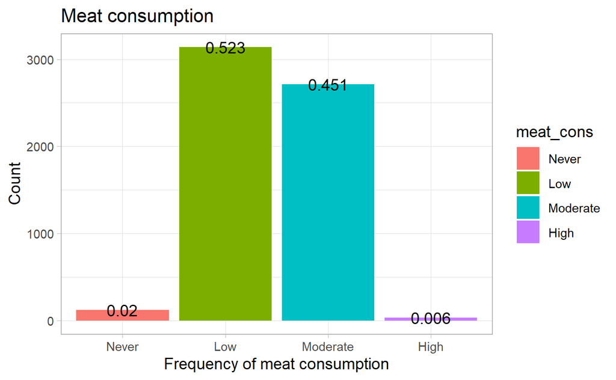

### 3.1.2 Diary Products

We create an array (dairy_vars) connecting our respondent number and all the variables of dairy products.

**Dairy product variables**

| SEQN | FFQ0007 | FFQ0108 | FFQ0109 | FFQ0110 | FFQ0111 | FFQ0112 | FFQ0137 | FFQ0138 |
| --- | --- | --- | --- | --- | --- | --- | --- | --- |
| 31129 | 6 | 1 | 1 | 3 | 7 | 3 | 1 | 1 |
| 31131 | 1 | 3 | 1 | 8 | 7 | 8 | 3 | 3 |
| 31132 | 1 | 1 | 1 | 5 | 1 | 5 | 1 | 1 |
| 31133 | NA | 5 | 1 | 7 | 1 | 5 | 1 | 5 |
| 31134 | 2 | 1 | 4 | 8 | 1 | 8 | 1 | 3 |
| 31139 | 7 | 1 | 1 | 1 | NA | 4 | 1 | 1 |

We merge all our dairy product variables to one variable `dairy_cons`.

**Diary products variable**

| SEQN | dairy_cons |
| --- | --- |
| 31129 | 3 |
| 31131 | 4 |
| 31132 | 2 |
| 31133 | 4 |
| 31134 | 4 |
| 31139 | 2 |

In order to understand the distribution of dairy products variable, we make a summary statistics.

```
#>    Min. 1st Qu.  Median    Mean 3rd Qu.    Max.
#>    1.00    3.00    4.00    3.74    4.00   10.00
```

we can see that most of the respondents eat dairy products around 1 time per month with a minimum of 1 (never), and a max of 10, meaning eating dairy products 1 time per day.

We change the value of variable `dairy_cons` from 1-11 to “never”, “low”, “moderate” and “high”, and we display a table to count the number and proportion of respondents according to the frequency of consumption of dairy products.

**Count and proportion of consumption of dairy products**

| dairy_cons | count | proportion |
| --- | --- | --- |
| never | 94 | 0.016 |
| low | 2509 | 0.418 |
| moderate | 3294 | 0.548 |
| high | 111 | 0.018 |

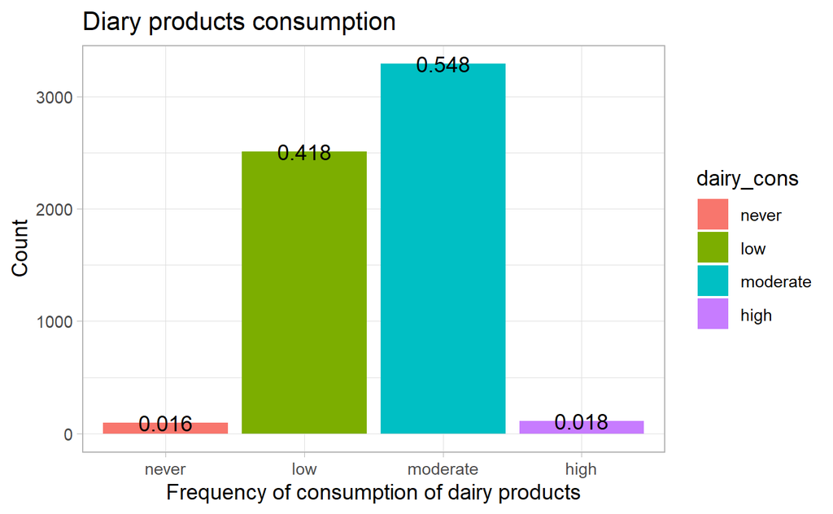

### 3.1.3 Vegetables

Here we explore our vegetable variable, we create an array (vege_var) connecting our respondent number and our vegetable variables.

**Vegetable variables**

| SEQN | FFQ0028 | FFQ0029 | FFQ0030 | FFQ0031 | FFQ0032 | FFQ0033 | FFQ0034 | FFQ0035 | FFQ0036 | FFQ0037 | FFQ0038 | FFQ0039 | FFQ0040 | FFQ0041 | FFQ0042 | FFQ0043 | FFQ0044 |
| --- | --- | --- | --- | --- | --- | --- | --- | --- | --- | --- | --- | --- | --- | --- | --- | --- | --- |
| 31129 | 7 | 2 | 2 | 3 | 2 | 8 | 8 | 1 | 7 | 5 | 8 | 5 | 5 | 8 | 1 | 2 | 5 |
| 31131 | 8 | 5 | 2 | 2 | 3 | 7 | 3 | 1 | 9 | 3 | 3 | 8 | 3 | 5 | 1 | 1 | 6 |
| 31132 | 3 | 2 | 2 | 1 | 8 | 8 | 5 | 1 | 2 | 2 | 1 | 2 | 5 | 3 | 1 | 2 | 9 |
| 31133 | 2 | 1 | 1 | 1 | 1 | 3 | 1 | 1 | 3 | 1 | 1 | 5 | 3 | 1 | 2 | 2 | 2 |
| 31134 | 1 | 1 | 3 | 3 | 7 | 7 | 3 | 1 | 3 | 3 | 3 | 7 | 5 | 1 | 1 | 1 | 8 |
| 31139 | 3 | 1 | 1 | 4 | 3 | 2 | 3 | 2 | 2 | 1 | 2 | 7 | 5 | 4 | 1 | 2 | 4 |

We merge all our vegetable variables to one variable `vege_cons`.

**Vegetable variable**

| SEQN | vege_cons |
| --- | --- |
| 31129 | 5 |
| 31131 | 4 |
| 31132 | 3 |
| 31133 | 2 |
| 31134 | 3 |
| 31139 | 3 |

In order to understand the distribution of vegetable variable, we make a summary statistics.

```
#>    Min. 1st Qu.  Median    Mean 3rd Qu.    Max.
#>     1.0     2.0     3.0     3.3     4.0    10.0
```

we can see that most of the respondents eat vegetables around 7-11 times per year with a minimum of 1 (never) and a max of 10, meaning eating vegetables products 1 time per day.

We change the value of variable `vege_cons` from 1 to 10 to “never”, “loW”, “moderate”, “high”, and display a table to count the number and proportion of respondents according to the frequency of vegetable consumption.

**Count and proportion of vegetable consumption**

| vege_cons | count | proportion |
| --- | --- | --- |
| never | 227 | 0.038 |
| low | 3330 | 0.555 |
| moderate | 2405 | 0.401 |
| high | 41 | 0.007 |

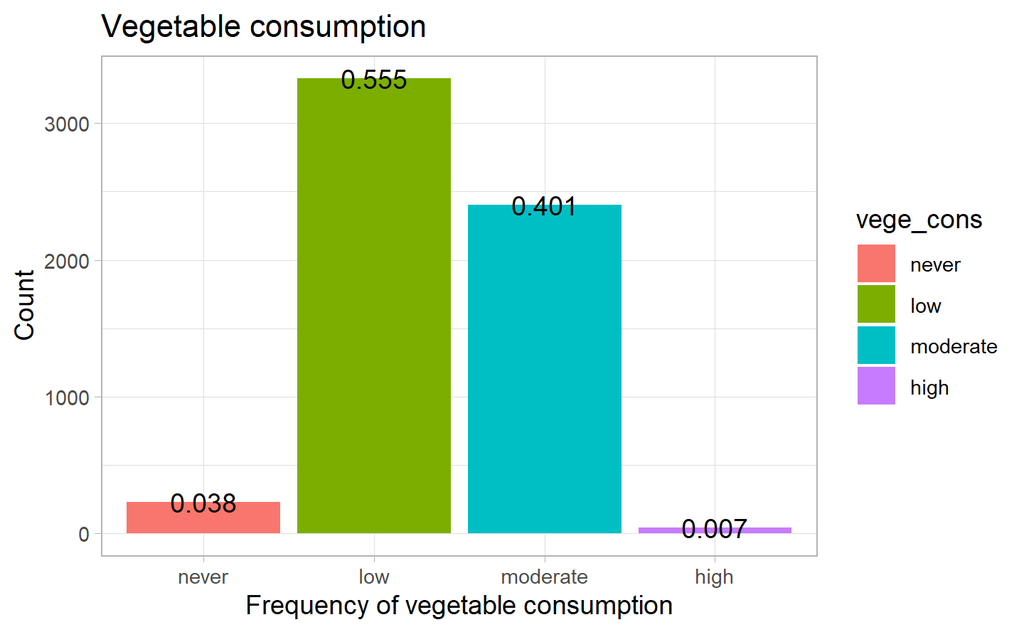

### 3.1.4 Fruits

Here we explore our fruits variable, we create an array (fruit_var) connecting our respondent number and our vegetable variable.

**fruit variables**

| SEQN | FFQ0015 | FFQ0016 | FFQ0017 | FFQ0018 | FFQ0019 | FFQ0020 | FFQ0021 | FFQ0022 | FFQ0023 | FFQ0024 | FFQ0025 | FFQ0026 | FFQ0027 |
| --- | --- | --- | --- | --- | --- | --- | --- | --- | --- | --- | --- | --- | --- |
| 31129 | 5 | 7 | 1 | 1 | 5 | 1 | 1 | 9 | 2 | 2 | 2 | 2 | 2 |
| 31131 | 8 | 5 | 1 | 8 | 5 | 7 | 1 | 8 | 1 | 1 | 1 | 2 | 6 |
| 31132 | 1 | 6 | 1 | 6 | 2 | 2 | 1 | 3 | 1 | 1 | 2 | 2 | 1 |
| 31133 | 3 | 2 | 1 | 2 | 1 | 1 | 1 | 3 | 1 | 1 | 1 | 2 | 3 |
| 31134 | 1 | 2 | 2 | 8 | 2 | 5 | 1 | 7 | 1 | 1 | 2 | 1 | 7 |
| 31139 | 1 | 8 | 1 | 10 | 1 | 1 | 1 | 1 | 1 | 1 | 2 | 2 | 1 |

**Fruit variable**

| SEQN | fruit_cons |
| --- | --- |
| 31129 | 3 |
| 31131 | 4 |
| 31132 | 2 |
| 31133 | 2 |
| 31134 | 3 |
| 31139 | 2 |

In order to understand the distribution of fruit variable, we make a summary statistics.

```
#>    Min. 1st Qu.  Median    Mean 3rd Qu.    Max.
#>    1.00    2.00    3.00    2.96    4.00   10.00
```

We change the value of variable `fruit_cons` from 1 to “never”, “low”, “moderate” and “high” and we display a table to count the number and proportion of respondents according to the frequency of fruit consumption.

**Count and proportion of fruit consumption**

| fruit_cons | count | proportion |
| --- | --- | --- |
| never | 171 | 0.028 |
| low | 4238 | 0.705 |
| moderate | 1591 | 0.265 |
| high | 10 | 0.002 |

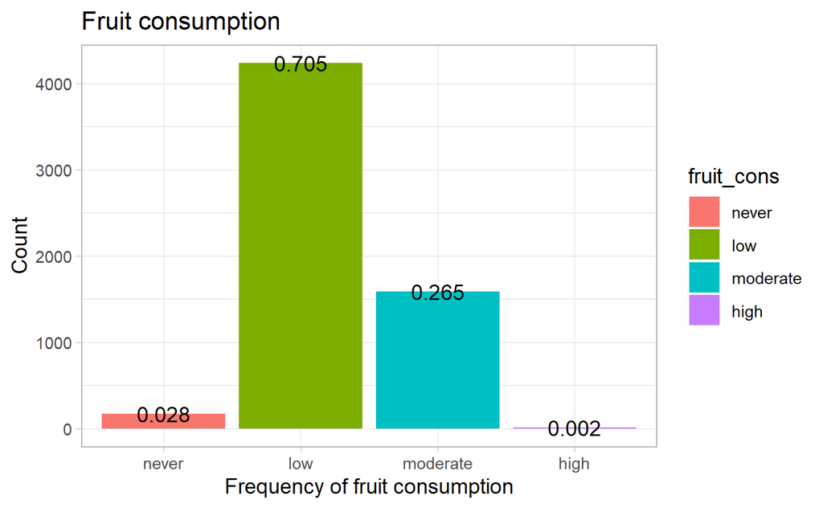

We can observe that the main frequency of fruit consumption of our respondents is in majority low(70.5%), then moderate(26.6%). There is 0% with a high consumption and 2.8% who never eat fruit.

### 3.1.5 Diet

Here we explore the type of diet, we create an array (Dietary_vars) connecting our respondent number and our vegetable variable.

**Diteray variables**

| SEQN | diet |
| --- | --- |
| 31130 | 3 |
| 31131 | 3 |
| 31132 | 2 |
| 31133 | 5 |
| 31134 | 3 |
| 31136 | 3 |

There are different categories defining how healthy the diet is :

1 = Excellent  
2 = Very good  
3 = Good  
4 = Fair  
5 = Poor  
7 = Refused  
9 = Don’t know

In order to understand the distribution of this `diet` variable, we make a summary statistics.

```
#>    Min. 1st Qu.  Median    Mean 3rd Qu.    Max.    NA's
#>       1       2       3       3       4       5    4222
```

The different categories are now changed to this :  
1-> Excellent  
2-> Very good  
3->Good  
4->Fair  
5->Poor  
7, 9->NA

**Dietary variables**

| SEQN | diet |
| --- | --- |
| 31130 | Good |
| 31131 | Good |
| 31132 | Very_good |
| 31133 | Poor |
| 31134 | Good |
| 31136 | Good |

We display a table to count the number and proportion of respondents.

**Diet - Count and proportion**

| diet | count | proportion |
| --- | --- | --- |
| Excellent | 559 | 0.091 |
| Very_good | 1290 | 0.211 |
| Good | 2401 | 0.392 |
| Fair | 1496 | 0.244 |
| Poor | 380 | 0.062 |

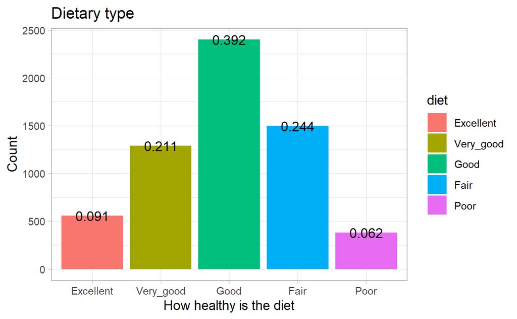

We can observe that the distribution is very similar to a normal distribution.

### 3.1.6 correlations

We create a table by joining all the previous food variables by their SEQN number to see if there is a correlation between them.

**Variables table**

| SEQN | meat_cons | dairy_cons | vege_cons | fruit_cons | diet |
| --- | --- | --- | --- | --- | --- |
| 31129 | 4 | 3 | 5 | 3 | NA |
| 31131 | 4 | 4 | 4 | 4 | 3 |
| 31132 | 3 | 2 | 3 | 2 | 2 |
| 31133 | 5 | 4 | 2 | 2 | 5 |
| 31134 | 5 | 4 | 3 | 3 | 3 |
| 31139 | 2 | 2 | 3 | 2 | 3 |

We then take a look at our correlations between variables, with a correlation matrix and correlation plot.

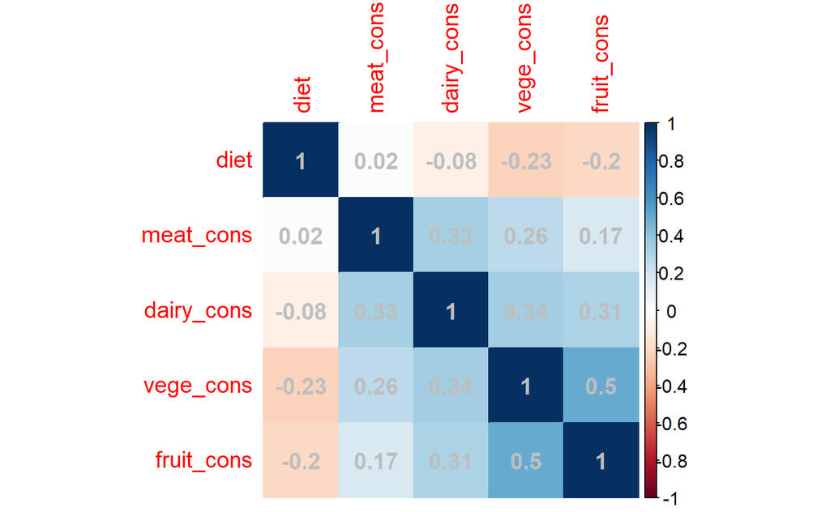

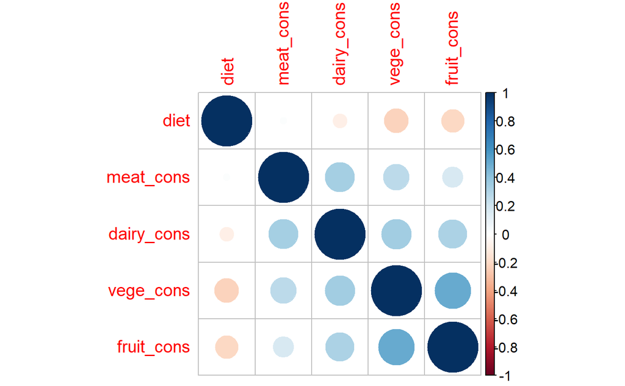

We can observe healthy diet is correlated with vegetable (-0, 23) and fruit (-0.2) so people who eat more vegetable and fruits tend to state more that they eat healthy. Also can observe that all the different consumption are positively correlated and particularly vegetable and and fruit consumption(0.5).

## 3.2 Non Food variables EDA

In this section, we will explore all the variables that could be linked to cancer but that are not classified as foods.

### 3.2.1 Age

We start first by the variable age, we create a table (age_var) with the variables `SEQN` and `RIDAGEYR` and then we rename `RIDAGEYR` to `age`.

**Age variable**

| SEQN | age |
| --- | --- |
| 31127 | 0 |
| 31128 | 11 |
| 31129 | 15 |
| 31130 | 85 |
| 31131 | 44 |
| 31132 | 70 |

```
#>    Min. 1st Qu.  Median    Mean 3rd Qu.    Max.
#>       0       9      19      28      45      85
```

We note that our respondent pool is rather young with 75% under 45 and half of our observation is under 19. In total, we have an average of 28 years. It is important to mention that people over 85 will always tick 85 as this is the maximum age.

We display a table to count the number of respondent and the proportion per age.

**Age count and proportion**

| age | count | proportion |
| --- | --- | --- |
| 0 | 526 | 0.051 |
| 1 | 359 | 0.035 |
| 2 | 353 | 0.034 |
| 18 | 316 | 0.031 |
| 16 | 299 | 0.029 |
| 15 | 298 | 0.029 |
| 12 | 293 | 0.028 |
| 17 | 277 | 0.027 |
| 13 | 275 | 0.027 |
| 19 | 268 | 0.026 |
| 14 | 262 | 0.025 |
| 4 | 249 | 0.024 |
| 5 | 230 | 0.022 |
| 3 | 219 | 0.021 |
| 6 | 211 | 0.020 |
| 10 | 205 | 0.020 |
| 9 | 193 | 0.019 |
| 8 | 187 | 0.018 |
| 11 | 176 | 0.017 |
| 7 | 173 | 0.017 |
| 85 | 170 | 0.016 |
| 29 | 118 | 0.011 |
| 25 | 116 | 0.011 |
| 23 | 114 | 0.011 |
| 22 | 110 | 0.011 |
| 26 | 109 | 0.011 |
| 24 | 108 | 0.010 |
| 40 | 107 | 0.010 |
| 20 | 102 | 0.010 |
| 21 | 102 | 0.010 |

[output cut: 56 more lines]

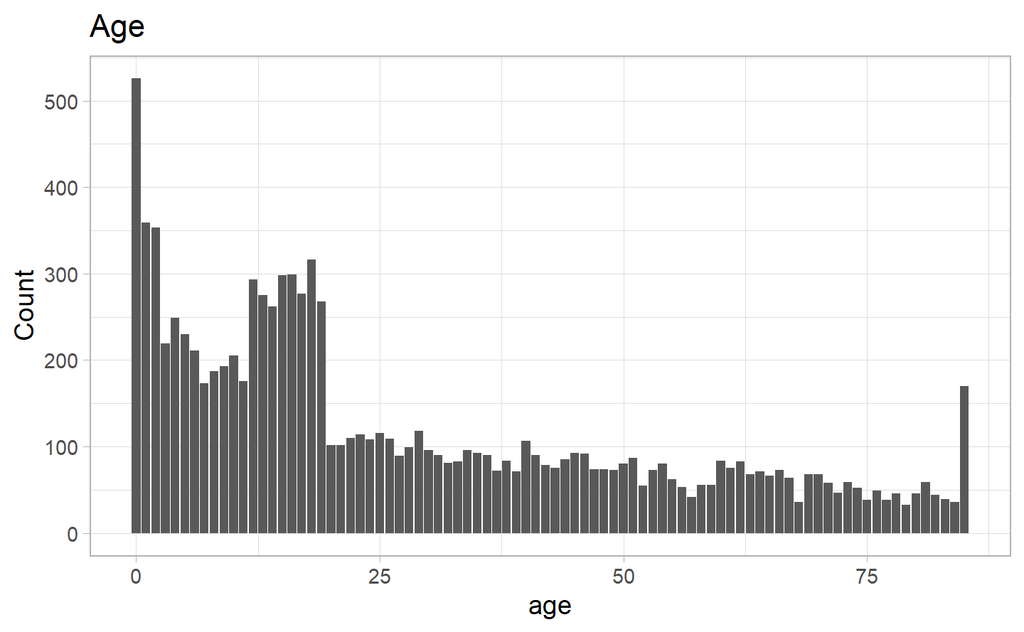

We regroup our data by categories of age.

**Age count and proportion by categories of age**

| age | count | proportion |
| --- | --- | --- |
| baby | 1457 | 0.141 |
| kid | 1917 | 0.185 |
| teenager | 1995 | 0.193 |
| young_adult | 1606 | 0.155 |
| adult | 1159 | 0.112 |
| young_senior | 1025 | 0.099 |
| senior | 1019 | 0.098 |
| senior_plus | 170 | 0.016 |

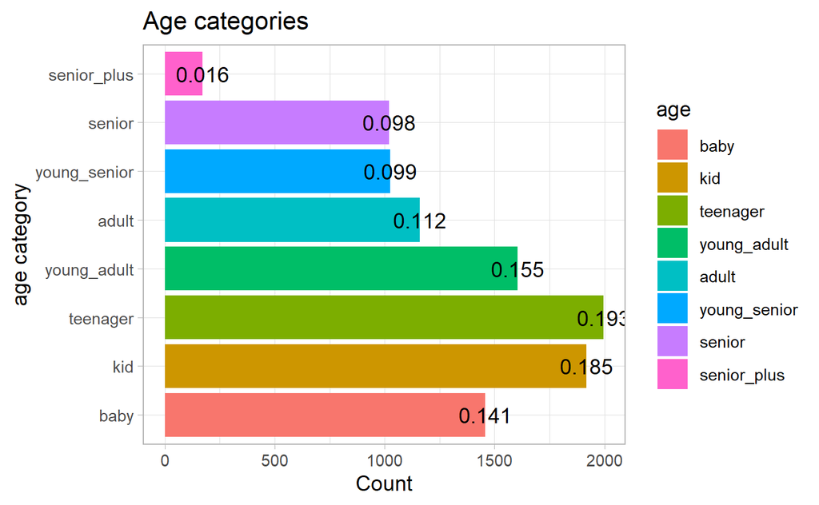

These plots and tables confirm our previous observation that our respondent pool is rather young.

### 3.2.2 Gender

We create a table(gender_var) with the variables `SEQN` and `RIAGENDR` and then we rename `RIAGENDR` to `gender`.

**Gender variable**

| SEQN | gender |
| --- | --- |
| 31127 | 1 |
| 31128 | 2 |
| 31129 | 1 |
| 31130 | 2 |
| 31131 | 2 |
| 31132 | 1 |

In order to understand the variable we make a summary statistics.

```
#>    Min. 1st Qu.  Median    Mean 3rd Qu.    Max.
#>    1.00    1.00    2.00    1.51    2.00    2.00
```

We display a table to count the number of respondents and the proportion by `gender`.

**Gender count and proportion**

| gender | count | proportion |
| --- | --- | --- |
| male | 5080 | 0.491 |
| female | 5268 | 0.509 |

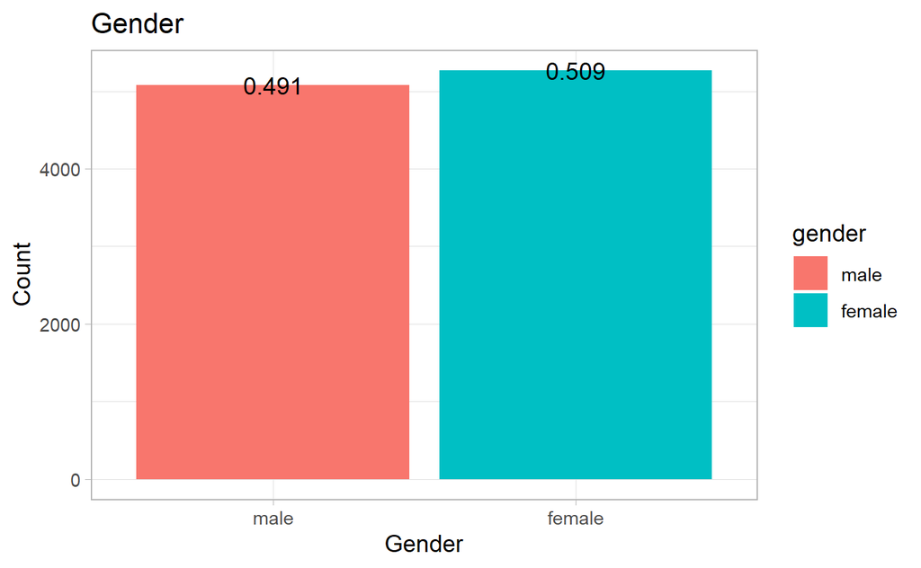

We can observe that the gender is fairly well balanced in general but there are 188 more women.

### 3.2.3 Income

We create a table(income_var) with the variables `SEQN` and `INDHHINC`, and we rename `INDHHINC` to `income`.

**income variable**

| SEQN | income |
| --- | --- |
| 31127 | 4 |
| 31128 | 8 |
| 31129 | 10 |
| 31130 | 4 |
| 31131 | 11 |
| 31132 | 11 |

It is important to know that in this variable, `income` is a numeric categorical variable, which refers to certain intervals:

-1 = $ 0 to $ 4, 999  
-2 = $ 5, 000 to $ 9, 999  
-3 = $10, 000 to $14, 999  
-4 = $15, 000 to $19, 999  
-5 = $20, 000 to $24, 999  
-6 = $25, 000 to $34, 999  
-7 = $35, 000 to $44, 999  
-8 = $45, 000 to $54, 999  
-9 = $55, 000 to $64, 999  
-10 = $65, 000 to $74, 999  
-11 = $75, 000 and Over  
-12 = Over $20, 000  
-13 = Under $20, 000

In order to understand the distribution of `income`, we make a summary statistics.

```
#>    Min. 1st Qu.  Median    Mean 3rd Qu.    Max.    NA's
#>       1       5       7       7      10      13     364
```

We can observe that our respondent pool has a median income and that the mean equal to 7, that is to say $ 35, 000 to $ 44, 999. 50% of our pool earn between $ 20, 000 and $ 74, 999 and 25% earn less than that and the other 25% earn more.

We display a table to count the number of respondent and the proportion by `income`.

**Income count and proportion**

| income | count | proportion |
| --- | --- | --- |
| 0-4, 999 | 255 | 0.026 |
| 5, 000-9, 999 | 428 | 0.043 |
| 10, 000-14, 999 | 803 | 0.080 |
| 15, 000-19, 999 | 801 | 0.080 |
| 20, 000-24, 999 | 818 | 0.082 |
| 25, 000-34, 999 | 1331 | 0.133 |
| 35, 000-44, 999 | 995 | 0.100 |
| 45, 000-54, 999 | 922 | 0.092 |
| 55, 000-64, 999 | 619 | 0.062 |
| 65, 000-74, 999 | 557 | 0.056 |
| 75, 000_and_Over | 2195 | 0.220 |
| Over_20, 000 | 186 | 0.019 |
| Under_20, 000 | 74 | 0.007 |

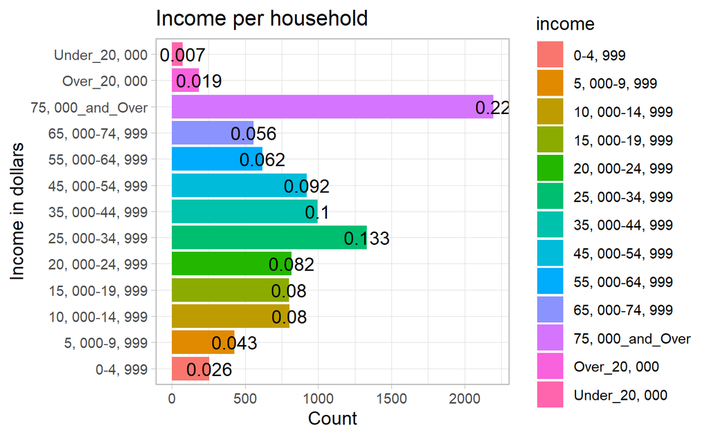

We can observe that in our pool of respondent, household earning more 75, 000$ dollars are over represented comparing to other categories.

### 3.2.4 physical activity

We create a table(physical_var) with our respondent number variable and then we rename `PAQ180` to `avg_physical_activity`.

**Physical activity variable**

| SEQN | avg_physical_activity |
| --- | --- |
| 31130 | 2 |
| 31131 | 1 |
| 31132 | 2 |
| 31133 | 3 |
| 31134 | 3 |
| 31136 | 1 |

It is important to mention that this variable is categorical and numeric, which refers to different levels of activity:

-1 {you sit/he/she sits} during the day and {do/does} not walk about very much.  
-2 {you stand or walk/he/she stands or walks} about a lot during the day, but {do/does}not have to carry or lift things very often  
-3 {you/he/she} lift(s) light load or {have/has} to climb stairs or hills often.  
-4 {you/he/she} {do/does} heavy work or {carry/carries} heavy loads.

In order to understand the distribution of physical activity, we make a summary statistics.

```
#>    Min. 1st Qu.  Median    Mean 3rd Qu.    Max.    NA's
#>       1       2       2       2       3       4    3291
```

We display a table to count the number of respondents and the proportion by physical activity.

**Physical activity count and proportion**

| avg_physical_activity | count | proportion |
| --- | --- | --- |
| no_activity | 1399 | 0.228 |
| low_activity | 3120 | 0.509 |
| moderate_activity | 1150 | 0.188 |
| intensive_activity | 464 | 0.076 |

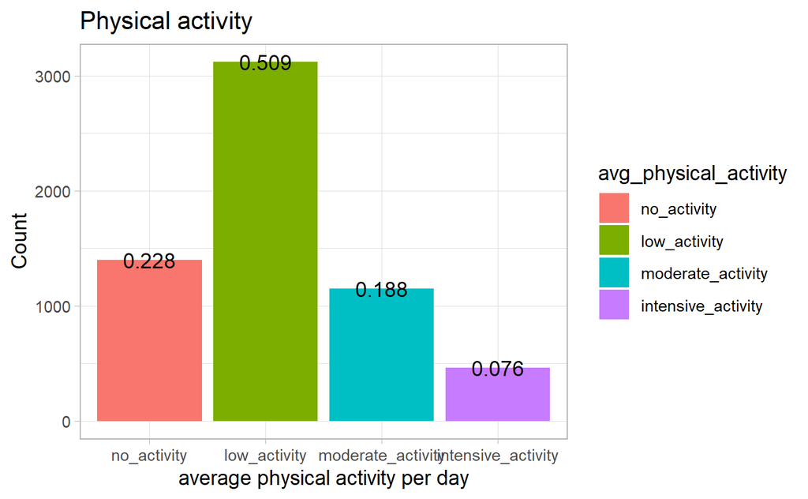

It is found that 22.8% have practically no physical activity, 50% have a light activity and 25% have a moderate or high physical activity.

### 3.2.5 Alcohol

we create a table(Alcohol_var) with our variable respondent number and `ALQ130`. Next, we rename `ALQ130` to `avg_alcohol`.

**Average consumption variable**

| SEQN | avg_alcohol |
| --- | --- |
| 31132 | 1 |
| 31134 | 2 |
| 31144 | 2 |
| 31150 | 3 |
| 31154 | 3 |
| 31158 | 2 |

In order to understand the distribution of the average alcohol consumption, we make a summary statistics.

```
#>    Min. 1st Qu.  Median    Mean 3rd Qu.    Max.    NA's
#>       1       1       2       3       3      32    1953
```

We display a table to count the number of respondent and the proportion by average alcohol drinks per day.

**Average alcohol consumption count and proportion**

| avg_alcohol | count | proportion |
| --- | --- | --- |
| 1 | 955 | 0.339 |
| 2 | 779 | 0.276 |
| 3 | 426 | 0.151 |
| 4 | 216 | 0.077 |
| 5 | 109 | 0.039 |
| 6 | 140 | 0.050 |
| 7 | 30 | 0.011 |
| 8 | 42 | 0.015 |
| 9 | 13 | 0.005 |
| 10 | 32 | 0.011 |
| 11 | 2 | 0.001 |
| 12 | 48 | 0.017 |
| 13 | 1 | 0.000 |
| 14 | 3 | 0.001 |
| 15 | 8 | 0.003 |
| 17 | 1 | 0.000 |
| 18 | 1 | 0.000 |
| 20 | 8 | 0.003 |
| 24 | 4 | 0.001 |
| 32 | 2 | 0.001 |

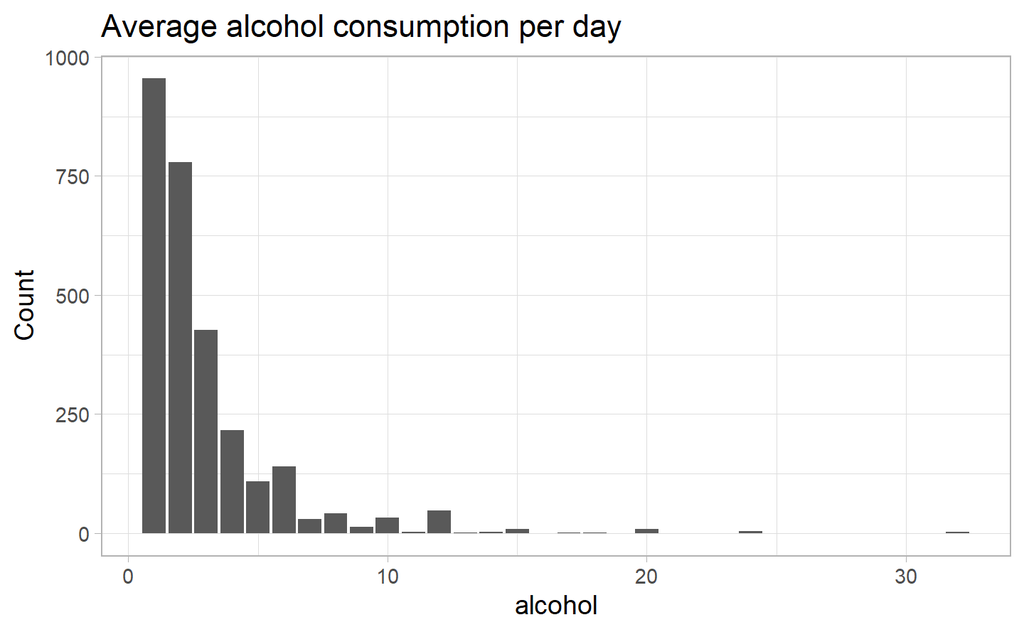

It can be seen that most respondents only drink 1 to 3 glasses per day but there is an impressive outlier with 32 glasses per day on average.

### 3.2.6 smoking

We create a table(Smoking_var) with our variable respondent number and `SMD070`. Then we rename `SMD070` to `cigarets_per_day`.

**Cigarettes per day variable**

| SEQN | cigarets_per_day |
| --- | --- |
| 31154 | 15 |
| 31158 | 20 |
| 31167 | 20 |
| 31186 | 1 |
| 31210 | 10 |
| 31253 | 15 |

It is important to note that it is not possible for us to know if a respondent does not smoke because this information was not requested. We therefore have no precise way of knowing whether a respondent’s noted NA is due to the fact that he is a non-smoker or if he did not respond.

```
#>    Min. 1st Qu.  Median    Mean 3rd Qu.    Max.    NA's
#>       1       9      15      16      20      90    6298
```

It can be seen that smokers smoke an average of 15 cigarettes and with the interquantile interval, we observe that 50% of smokers smoke 9 to 20 cigarettes per day. There is also an impressive maximum of 90 cigarettes smoked per day.

We display a table to count the number of respondents and the proportion of cigarettes smoked per day

**Average cigarettes smoked per day count and proportion**

| cigarets_per_day | count | proportion |
| --- | --- | --- |
| 1 | 29 | 0.033 |
| 2 | 9 | 0.010 |
| 3 | 31 | 0.035 |
| 4 | 29 | 0.033 |
| 5 | 46 | 0.052 |
| 6 | 27 | 0.030 |
| 7 | 23 | 0.026 |
| 8 | 26 | 0.029 |
| 9 | 3 | 0.003 |
| 10 | 168 | 0.189 |
| 11 | 1 | 0.001 |
| 12 | 21 | 0.024 |
| 13 | 2 | 0.002 |
| 14 | 2 | 0.002 |
| 15 | 57 | 0.064 |
| 16 | 7 | 0.008 |
| 17 | 4 | 0.005 |
| 18 | 9 | 0.010 |
| 19 | 2 | 0.002 |
| 20 | 244 | 0.275 |
| 22 | 2 | 0.002 |
| 24 | 1 | 0.001 |
| 25 | 17 | 0.019 |
| 26 | 2 | 0.002 |
| 27 | 1 | 0.001 |
| 30 | 61 | 0.069 |
| 35 | 4 | 0.005 |
| 40 | 47 | 0.053 |
| 45 | 1 | 0.001 |
| 50 | 7 | 0.008 |
| 60 | 4 | 0.005 |
| 90 | 1 | 0.001 |

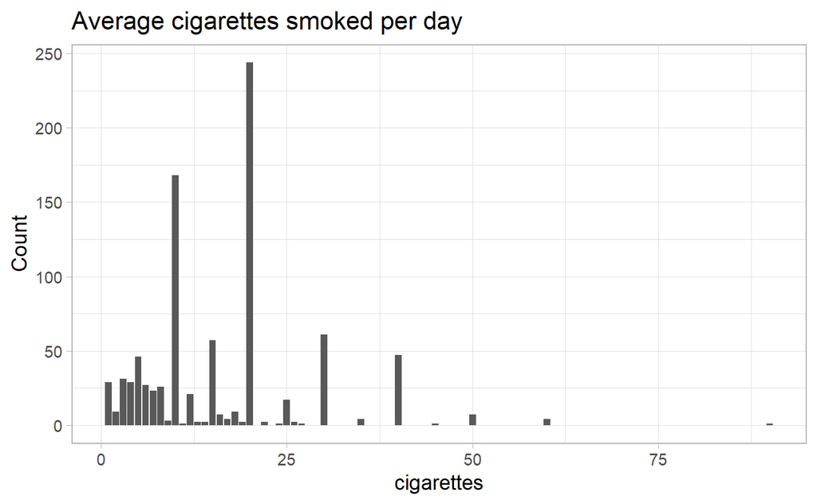

Here we can clearly see that the respondents approximated their number of cigarettes smoked because most of them answer either 5-10-15-20-30-40. This reminds us that our data is based on declarative observations and is not precise.

### 3.2.7 Correlations

We create a table by joining all the previous non-food related variables by their SEQN number to examine their correlations.

**Other variables table**

| SEQN | age | gender | income | avg_physical_activity | avg_alcohol | cigarets_per_day |
| --- | --- | --- | --- | --- | --- | --- |
| 31130 | 85 | 2 | 4 | 2 | NA | NA |
| 31131 | 44 | 2 | 11 | 1 | NA | NA |
| 31132 | 70 | 1 | 11 | 2 | 1 | NA |
| 31134 | 73 | 1 | 12 | 3 | 2 | NA |
| 31144 | 21 | 1 | 3 | 2 | 2 | NA |
| 31149 | 85 | 2 | 1 | 1 | NA | NA |

We then examine our correlations between variables with a correlation matrix and a correlation graph.

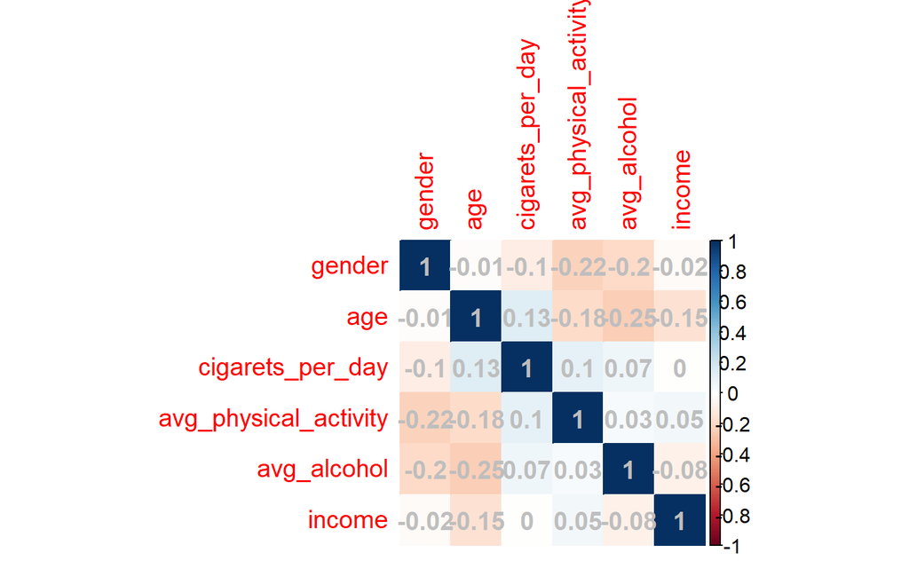

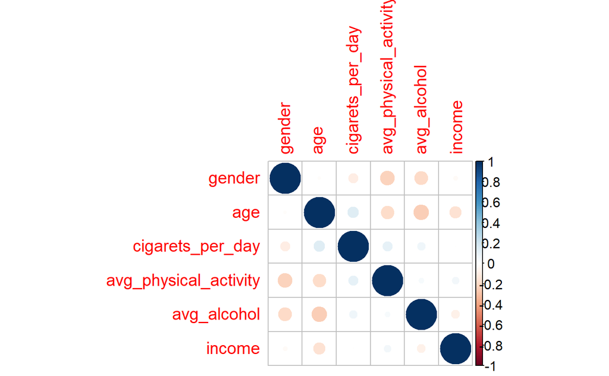

There are no strong correlations between the variables. Our highest correlations are :  
- Age and average alcohol consumption -24.67%  
- Gender and physical activity -22.30%, Gender and alcohol consumption -20%  
So this suggests that women do less physical activity, and drink less alcohol, and older people drink less alcohol, these correlations are not strong, but have to be considered. Other correlations are weak.

## 3.3 Cancer EDA

In this section, we will explore our variables on cancer. Later, we will regroup all our variables seen previously and we will explore the relationships with cancer and finally we will model it, in part 4.

### 3.3.1 Had cancer

We create a table (cancer_var) with our variable respondent number and `MCQ220` which we will rename `got_cancer`, this variable got_cancer is the one that we will try to find relationship and to model in our analysis.

**Ever had cancer variable**

| SEQN | got_cancer |
| --- | --- |
| 31130 | 0 |
| 31131 | 0 |
| 31132 | 0 |
| 31134 | 0 |
| 31136 | 0 |
| 31144 | 0 |

Our variable got_cancer can only take two values, either 0 if no cancer or 1 if ever had cancer.

We display a table to count the number of respondents and the proportion who ever had cancer or not.

**Ever had cancer count and proportion**

| got_cancer | count | proportion |
| --- | --- | --- |
| 0 | 4561 | 0.917 |
| 1 | 414 | 0.083 |

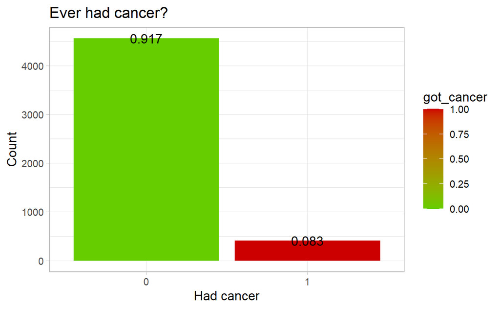

We can observe that 8.3% of our respondents have already had cancer once in their life. You might think this number is high, but in fact it is quite low because we know the lifetime probability of getting cancer is around 40% from the american cancer of society : https://www.cancer.org/cancer/cancer-basics/lifetime-probability-of-developing-or-dying-from-cancer.html  
This small result could be due to several reasons, one of which may be because our respondent pool is rather young, as we observed above.

### 3.3.2 Cancer types

We create a table(cancer_type_var) with our variables respondent number `SEQN`, `MCQ230A`, `MCQ230B` , `MCQ230C` that we will rename to `cancer_typeQ1`, `cancer_typeQ2` and `cancer_typeQ3`.

**Type of Cancer**

| SEQN | cancer_typeQ1 | cancer_typeQ2 | cancer_typeQ3 |
| --- | --- | --- | --- |
| 31149 | 16 | NA | NA |
| 31150 | 16 | NA | NA |
| 31208 | 39 | NA | NA |
| 31214 | 14 | NA | NA |
| 31233 | 32 | NA | NA |
| 31243 | 30 | NA | NA |

Now that some respondents have had cancer several times, we need to change the way our data is displayed and for that we use the “pivot longer” function to have only one variable with the type of cancer.

**Type of cancer count and proportion**

| type | count | proportion |
| --- | --- | --- |
| Skin_non_melanoma | 79 | 0.173 |
| Breast | 77 | 0.168 |
| Prostate | 62 | 0.136 |
| Cervix | 43 | 0.094 |
| Skin | 33 | 0.072 |
| Melanoma | 26 | 0.057 |
| Colon | 24 | 0.053 |
| Uterus | 19 | 0.042 |
| Other | 19 | 0.042 |
| Lung | 11 | 0.024 |
| Ovary | 10 | 0.022 |
| Lymphoma | 9 | 0.020 |
| Bladder | 8 | 0.018 |
| Thyroid | 8 | 0.018 |
| Kidney | 5 | 0.011 |
| Mouth/tong | 3 | 0.007 |
| Rectum | 3 | 0.007 |
| Stomach | 3 | 0.007 |
| Blood | 2 | 0.004 |
| Bone | 2 | 0.004 |
| Brain | 2 | 0.004 |
| Esophagus | 2 | 0.004 |
| Larynx | 2 | 0.004 |
| Liver | 2 | 0.004 |
| Leukemia | 1 | 0.002 |
| Soft_tissue | 1 | 0.002 |
| Testicular | 1 | 0.002 |

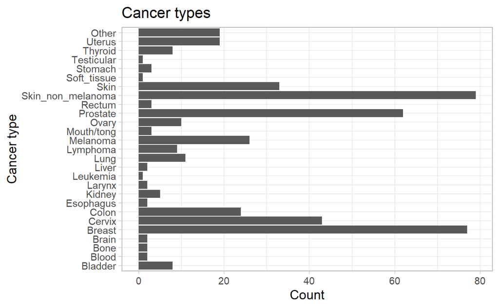

It is observed that the most frequent cancers are breast, non-melanoma skin, prostate and cervical cancers.

## 3.4 Relation between food variables and others

In this section, we will study the correlations between the variables related to food and our other variables (age, income, smoking, etc.)

### 3.4.1 correlations

We first create a table: join_food_other_var, where we will merge all our food and non-food variables. Then we will explore if there are strong correlations between them.

**Food variables and others**

| SEQN | age | gender | income | avg_physical_activity | avg_alcohol | cigarets_per_day | meat_cons | dairy_cons | vege_cons | fruit_cons | diet |
| --- | --- | --- | --- | --- | --- | --- | --- | --- | --- | --- | --- |
| 31131 | 44 | 2 | 11 | 1 | NA | NA | 4 | 4 | 4 | 4 | 3 |
| 31132 | 70 | 1 | 11 | 2 | 1 | NA | 3 | 2 | 3 | 2 | 2 |
| 31134 | 73 | 1 | 12 | 3 | 2 | NA | 5 | 4 | 3 | 3 | 3 |
| 31144 | 21 | 1 | 3 | 2 | 2 | NA | 5 | 7 | 6 | 5 | 1 |
| 31150 | 79 | 1 | 3 | 4 | 3 | NA | 3 | 4 | 6 | 4 | 4 |
| 31151 | 59 | 2 | 7 | 1 | NA | NA | 2 | 3 | 3 | 2 | 4 |

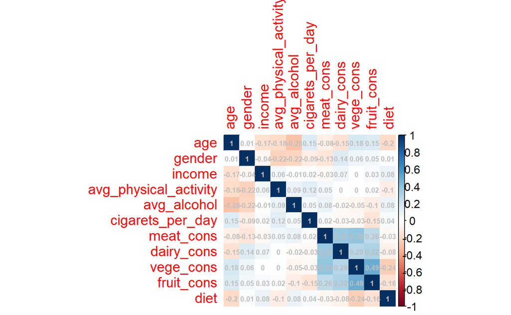

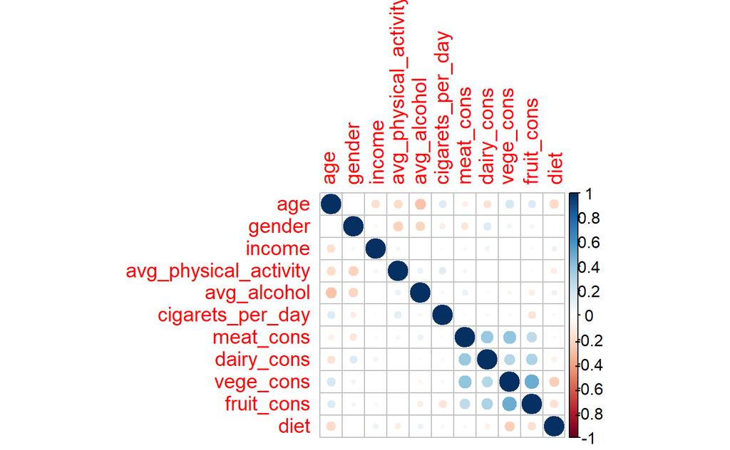

There are no strong correlations between the food variables and the other variables, only age and gender seem to have small correlations. we can observe that there is a correlation of -0.2 between age and diet, which means that older people would eat healthier.  
We also see that age is negatively correlated with the consumption of dairy products (-0.15) and positively correlated with the consumption of vegetables ( + 0.18) as well as with the consumption of fruits ( + 0.15), which would mean that the lower the age, the higher the consumption of dairy products is, and the smaller fruits and vegetables consumption is.  
Regarding gender, we can observe a negative correlation with the consumption of meat (-0.13) and a positive correlation with the consumption of dairy products ( + 0.14), which means that women tend to eat a little less meat and a little more dairy than men, according to our data.  
On the other hand, there is no correlation between gender and diet, consumption of vegetables and consumption of fruits. Smoking is also a little negatively correlated with fruit consumption (-0.15).

### 3.4.2 Most correlated variables investigation

Based on the correlation, we study the relationships between our variables age, gender, meat_cons, dairy_cons, vege_cons, fruit_cons.

**Age, Gender and Food variables**

| SEQN | age | gender | meat_cons | dairy_cons | vege_cons | fruit_cons |
| --- | --- | --- | --- | --- | --- | --- |
| 31129 | teenager | male | 4 | 3 | 5 | 3 |
| 31131 | adult | female | 4 | 4 | 4 | 4 |
| 31132 | senior | male | 3 | 2 | 3 | 2 |
| 31133 | teenager | female | 5 | 4 | 2 | 2 |
| 31134 | senior | male | 5 | 4 | 3 | 3 |
| 31139 | teenager | female | 2 | 2 | 3 | 2 |

We make a a table of the average consumption by `age` and by `gender`.

**Average consumption of meat, dairy products, vegetables, fruits by age and gender categories**

| age | gender | avg_meat_cons | avg_dairy_cons | avg_vege_cons | avg_fruit_cons |
| --- | --- | --- | --- | --- | --- |
| baby | male | 4 | 5 | 3 | 4 |
| baby | female | 4 | 5 | 4 | 4 |
| kid | male | 4 | 5 | 3 | 4 |
| kid | female | 4 | 5 | 4 | 4 |
| teenager | male | 4 | 4 | 3 | 3 |
| teenager | female | 4 | 4 | 3 | 3 |
| young_adult | male | 4 | 4 | 4 | 3 |
| young_adult | female | 4 | 4 | 4 | 3 |
| adult | male | 4 | 4 | 4 | 3 |
| adult | female | 4 | 4 | 4 | 3 |
| young_senior | male | 4 | 4 | 4 | 3 |
| young_senior | female | 4 | 4 | 4 | 3 |
| senior | male | 4 | 4 | 4 | 3 |
| senior | female | 4 | 4 | 4 | 4 |
| senior_plus | male | 3 | 4 | 4 | 4 |
| senior_plus | female | 3 | 4 | 4 | 4 |

This table shows us that the consumption of dairy products is more present in babies and children after this period the consumption of milk dairy products decreases. Another thing that we could point out would be that babies, children and the elderly eat a little more fruit than adolescents, young people and adults. We don’t see the effect of gender.

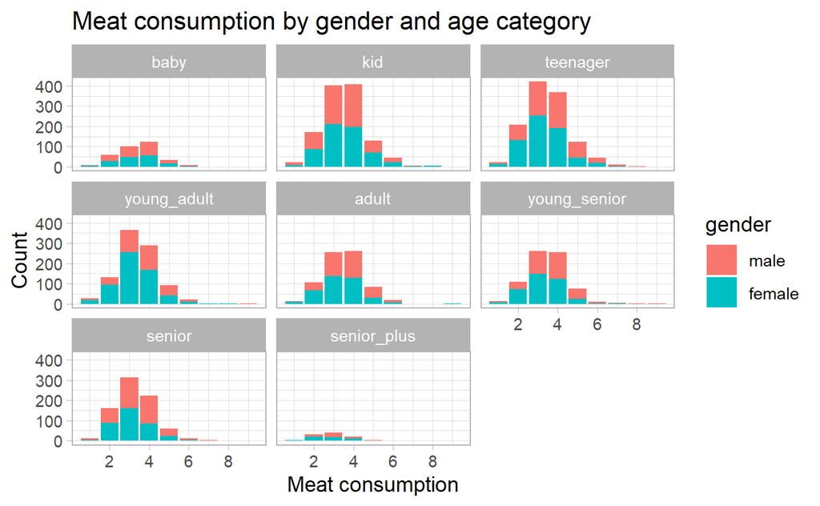

We can observe that the consumption of meat increases during growth i.e. from kid to teenager but this relationship stops from teenager and takes the opposite turn, the consumption of meat decreases later from teenager to senior plus.  
It can also be noted that the consumption of men is higher than that of women, as we observe a higher proportion in the high frequencies and a smaller in low frequencies.

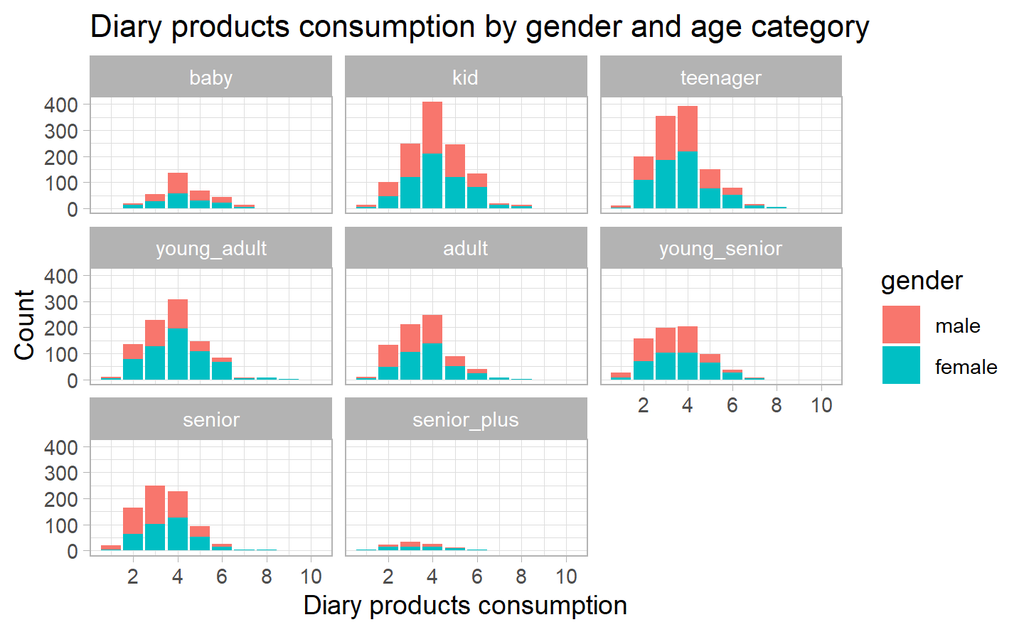

Regarding now the consumption of dairy products, we can see that babies, kids, and teenagers consume more often dairy products. In addition, the majority of them consume these products once a month in general and women who consume more dairy products, as we can observe high proportion in higher frequencies.

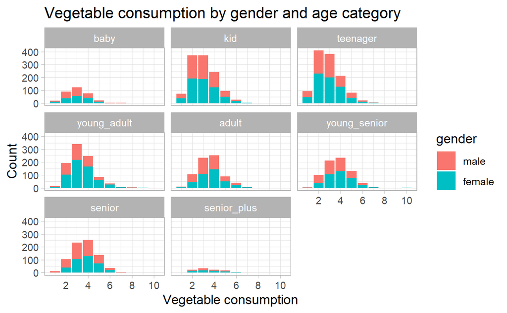

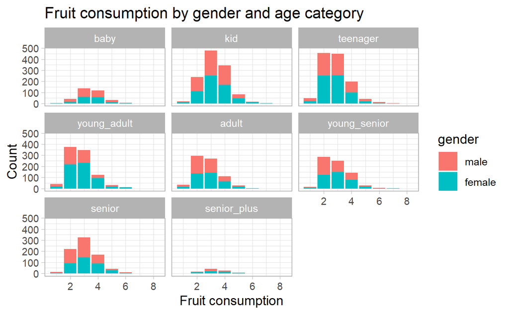

We don’t see any an effect of age, but we can see that women eat more fruit, as the proportion of female increase in the higher frequencies.

## 3.5 Most important observations recap

About food variables:  
we combined and merged the variables into a single variable based on its type, then grouped them into frequency categories. This gave us observations on the frequency of food consumption that were mostly low or moderate. There are no correlations that we could consider important or strong, however there is a slight correlation that we can note is that between the consumption of vegetables and fruits (corr = 0.5).

About cancer variables:  
8.3% of respondents have had cancer at least once in their life. The most frequent cancers are that of the breast, that of non-melanoma, that of the prostate and finally that of the cervix. The relationship between cancer and other variables will be explored in depth in the analysis section.

About the relationship between food variables and other variables:  
There are no strong correlations, only age and sex are slightly correlated with food variables.

# **4 Analysis**

## 4.1 Approach and Method

We will begin our analysis on the different variables that can influence cancer, by examining the direct relationship between cancer and each of our non-food variables, then we will examine the relationship between cancer and each of our food variables which will be examined further in the detail and depth compared to other variables.

For the non-food variables, we will establish a proportion barplot then we will look at the p-value of the coefficient and so if the latter is significant then it will be integrated into a generalized linear model. For food variables, we will do the same thing but in addition, we will model their individual effects on cancer and we will illustrate the regression.

Finally, we will select all variables significant at the 5% level and train a multivariate model with those selected variables, then we will compare this model to a full model including all variables. We chose the GLM regression with the binary method, because the variable we want to predict “got_cancer” is binary as it takes the value 0 if the respondent has never had cancer and the value of 1 if the respondent has already had cancer. cancer.

At the start of our project, we only wanted to take into account the variables related to our research questions but finally we decided to widen our scope by including more variables that could be confounding, and influence or impact our results.

For the analysis, we create a table where we group all our data so all our explanatory variables, this table will be useful to explain `got_cancer`.

**cancer, food and other variables**

| SEQN | got_cancer | age | gender | income | avg_physical_activity | avg_alcohol | cigarets_per_day | meat_cons | dairy_cons | vege_cons | fruit_cons | diet |
| --- | --- | --- | --- | --- | --- | --- | --- | --- | --- | --- | --- | --- |
| 31131 | 0 | 44 | 2 | 11 | 1 | NA | NA | 4 | 4 | 4 | 4 | 3 |
| 31132 | 0 | 70 | 1 | 11 | 2 | 1 | NA | 3 | 2 | 3 | 2 | 2 |
| 31134 | 0 | 73 | 1 | 12 | 3 | 2 | NA | 5 | 4 | 3 | 3 | 3 |
| 31144 | 0 | 21 | 1 | 3 | 2 | 2 | NA | 5 | 7 | 6 | 5 | 1 |
| 31150 | 1 | 79 | 1 | 3 | 4 | 3 | NA | 3 | 4 | 6 | 4 | 4 |
| 31151 | 0 | 59 | 2 | 7 | 1 | NA | NA | 2 | 3 | 3 | 2 | 4 |

## 4.2 Cancer and non food variables

In this section, we will briefly study the relationship with `got_cancer` and the variables which are not related to our research questions but which may have an impact on our interpretation. To study them, we will observe the proportion of cancer as well as the individual significance to determine if these variables would be useful for modeling `got_cancer`.

## 4.2.1 Cancer and age

We create a table including our `got_cancer` and `age` variables.

**Cancer and age variables**

| SEQN | age | got_cancer |
| --- | --- | --- |
| 31130 | senior_plus | 0 |
| 31131 | adult | 0 |
| 31132 | senior | 0 |
| 31134 | senior | 0 |
| 31136 | adult | 0 |
| 31144 | young_adult | 0 |

We display a table and a barplot to count the number of cancers and the proportion by age categories.

**Cancer by age categories**

| age | got_cancer | count | proportion |
| --- | --- | --- | --- |
| baby | NA | 0 | NaN |
| kid | NA | 0 | NaN |
| teenager | NA | 0 | NaN |
| young_adult | 0 | 1587 | 0.988 |
| young_adult | 1 | 19 | 0.012 |
| adult | 0 | 1112 | 0.959 |
| adult | 1 | 47 | 0.041 |
| young_senior | 0 | 938 | 0.917 |
| young_senior | 1 | 85 | 0.083 |
| senior | 0 | 803 | 0.789 |
| senior | 1 | 215 | 0.211 |
| senior_plus | 0 | 121 | 0.716 |
| senior_plus | 1 | 48 | 0.284 |

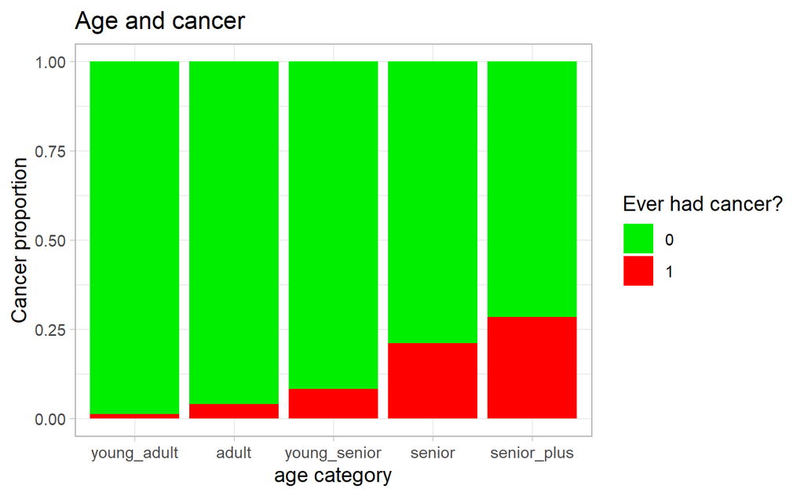

We can observe that we have no data about babies, kid and teenagers. We can clearly see that the older the respondents, the greater the proportion of them who have had cancer.

We would like to see the effect of the coefficient and if its p-value is significant.

```
#> [1] "coefficient"
#> [1] 0.0635
#> [1] "p-value"
#> [1] 0.000000000000000000000000000000000000000000000000000775
```

We can see that the coefficient has a small positive effect on cancer, but it is significant because its value is close to 0, this variable will be useful for our partial multivariate mode.

## 4.2.2 Cancer and gender

We create a table including our `got_cancer` and `gender` variables.

**Cancer and gender**

| SEQN | gender | got_cancer |
| --- | --- | --- |
| 31130 | female | 0 |
| 31131 | female | 0 |
| 31132 | male | 0 |
| 31134 | male | 0 |
| 31136 | female | 0 |
| 31144 | male | 0 |

We display a table and a barplot to count the number of cancers and the proportion by gender.

**Cancer by gender**

| gender | got_cancer | count | proportion |
| --- | --- | --- | --- |
| male | 0 | 2204 | 0.924 |
| male | 1 | 181 | 0.076 |
| female | 0 | 2357 | 0.910 |
| female | 1 | 233 | 0.090 |

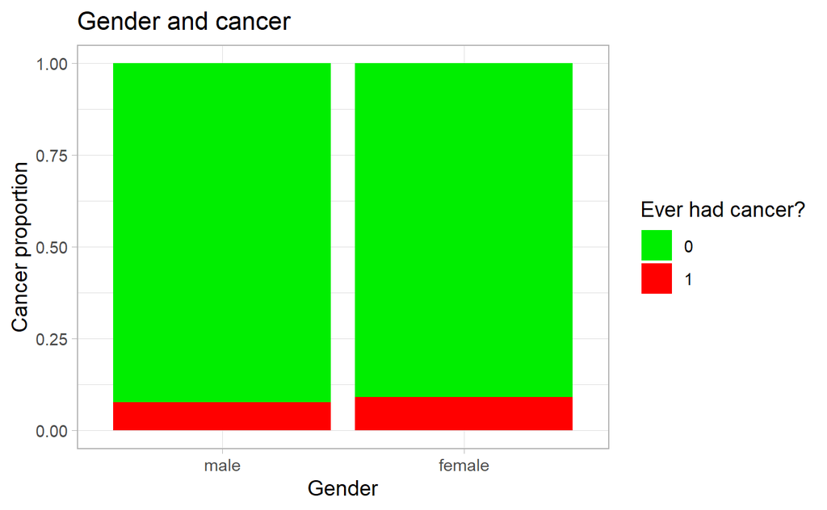

There is a small difference between men (7.6%) and women (9%), it is necessary to know if this difference of 1.4% is significant or not.

We would like to see the effect of the coefficient and if its p-value is significant.

```
#> [1] "coefficient"
#> [1] 0.0599
#> [1] "p-value"
#> [1] 0.625
```

## 4.2.3 Cancer and income

We create a table including `got_cancer` and `income` variables.

**Cancer and income**

| SEQN | income | got_cancer |
| --- | --- | --- |
| 31130 | 15, 000-19, 999 | 0 |
| 31131 | 75, 000_and_Over | 0 |
| 31132 | 75, 000_and_Over | 0 |
| 31134 | Over_20, 000 | 0 |
| 31136 | 35, 000-44, 999 | 0 |
| 31144 | 10, 000-14, 999 | 0 |

We display a table and a barplot to count the number of cancers and the proportion by income categories.

**Cancer by income categories**

| income | got_cancer | count | proportion |
| --- | --- | --- | --- |
| 0-4, 999 | 0 | 78 | 0.918 |
| 0-4, 999 | 1 | 7 | 0.082 |
| 5, 000-9, 999 | 0 | 198 | 0.938 |
| 5, 000-9, 999 | 1 | 13 | 0.062 |
| 10, 000-14, 999 | 0 | 311 | 0.899 |
| 10, 000-14, 999 | 1 | 35 | 0.101 |
| 15, 000-19, 999 | 0 | 309 | 0.878 |
| 15, 000-19, 999 | 1 | 43 | 0.122 |
| 20, 000-24, 999 | 0 | 342 | 0.927 |
| 20, 000-24, 999 | 1 | 27 | 0.073 |
| 25, 000-34, 999 | 0 | 577 | 0.902 |
| 25, 000-34, 999 | 1 | 63 | 0.098 |
| 35, 000-44, 999 | 0 | 450 | 0.916 |
| 35, 000-44, 999 | 1 | 41 | 0.084 |
| 45, 000-54, 999 | 0 | 439 | 0.911 |
| 45, 000-54, 999 | 1 | 43 | 0.089 |
| 55, 000-64, 999 | 0 | 298 | 0.937 |
| 55, 000-64, 999 | 1 | 20 | 0.063 |
| 65, 000-74, 999 | 0 | 258 | 0.938 |
| 65, 000-74, 999 | 1 | 17 | 0.062 |
| 75, 000_and_Over | 0 | 1027 | 0.931 |
| 75, 000_and_Over | 1 | 76 | 0.069 |
| Over_20, 000 | 0 | 94 | 0.862 |
| Over_20, 000 | 1 | 15 | 0.138 |
| Under_20, 000 | 0 | 23 | 0.958 |
| Under_20, 000 | 1 | 1 | 0.042 |

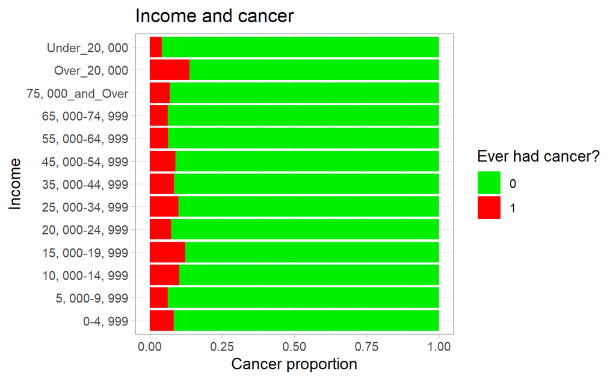

We don’t see any trend in the relationship between income and cancer, our data does not suggest that income is related to cancer.

We would like to see the effect of the coefficient and if its p-value is significant.

```
#> [1] "Coefficient"
#> [1] -0.0347
#> [1] "p-value"
#> [1] 0.0936
```

We can see that the coefficient has a small negative effect on cancer, but it is only significant at the 0.10 level. So this variable will only be used in the full model.

## 4.2.4 Cancer and physical activity

We create a table including `got_cancer` and `avg_physical_activity` variables.

**Cancer and physical activity**

| SEQN | avg_physical_activity | got_cancer |
| --- | --- | --- |
| 31130 | low_activity | 0 |
| 31131 | no_activity | 0 |
| 31132 | low_activity | 0 |
| 31134 | moderate_activity | 0 |
| 31136 | no_activity | 0 |
| 31144 | low_activity | 0 |

We display a table and a barplot to count the number of cancer and the proportion by income categories.

**Cancer by physical activity**

| avg_physical_activity | got_cancer | count | proportion |
| --- | --- | --- | --- |
| no_activity | 0 | 1067 | 0.898 |
| no_activity | 1 | 121 | 0.102 |
| low_activity | 0 | 2324 | 0.924 |
| low_activity | 1 | 192 | 0.076 |
| moderate_activity | 0 | 794 | 0.904 |
| moderate_activity | 1 | 84 | 0.096 |
| intensive_activity | 0 | 371 | 0.959 |
| intensive_activity | 1 | 16 | 0.041 |

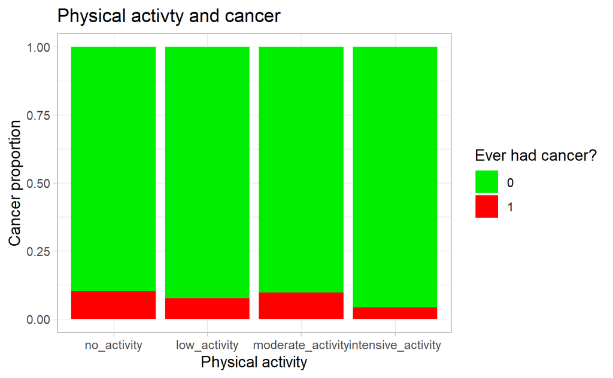

We do not see any particular trend, respondents with intensive activity have a little less cancer 4.1% while the others have around 9%.

We would like to see the effect of the coefficient and if its p-value is significant.

```
#> [1] "coefficient"
#> [1] -0.0639
#> [1] "p-value"
#> [1] 0.398
```

We can see that the coefficient has a small negative effect on cancer but it is not significant since the p-value is very large. This variable will only be used in the full model.

## 4.2.5 Cancer and alcohol

We create a table including `got_cancer` and `avg_alcohol` variables.

**Cancer and Average alcohol consumption**

| SEQN | avg_alcohol | got_cancer |
| --- | --- | --- |
| 31130 | NA | 0 |
| 31131 | NA | 0 |
| 31132 | 1 | 0 |
| 31134 | 2 | 0 |
| 31144 | 2 | 0 |
| 31149 | NA | 1 |

About this variable `avg_alcohol`, it’s a bit special because we only have the information on the number of drinks, but there is no answer if the respondents do not drink, so the undetermined proportion (NA), maybe people who didn’t answer because they don’t drink alcohol at all, or it could just be people who didn’t answer the question.

We are now investigating whether people who did not respond about their alcohol consumption have a different proportion of cancer, but these results need to be taken with a lot of hindsight.

**declared alcohol drinkers and cancer**

| drink | got_cancer | count | proportion |
| --- | --- | --- | --- |
| unknown | 0 | 1761 | 0.903 |
| unknown | 1 | 190 | 0.097 |
| yes | 0 | 2613 | 0.927 |
| yes | 1 | 205 | 0.073 |

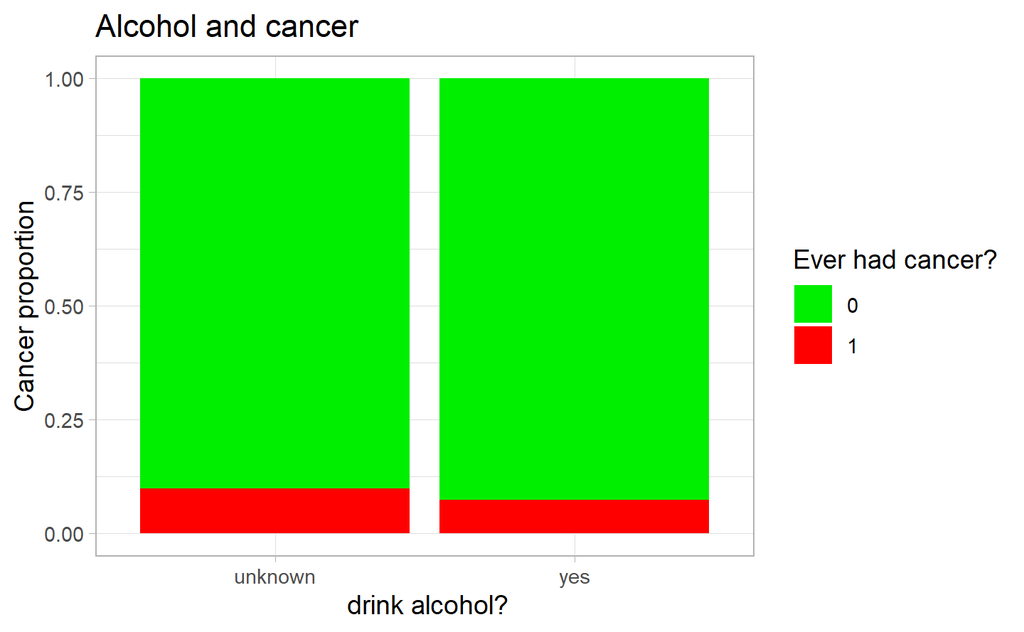

We observe that people who say they drink have less cancer (7.3%) than those who did not answer the question (9.7%).

Next we want to look at the amount of drinks per day and cancer. We make a table with proportion in number of drinks and a scatterplot.

**Alcohol quantity and cancer**

| avg_alcohol | got_cancer | count | proportion |
| --- | --- | --- | --- |
| 1 | 0 | 848 | 0.888 |
| 1 | 1 | 107 | 0.112 |
| 2 | 0 | 723 | 0.929 |
| 2 | 1 | 55 | 0.071 |
| 3 | 0 | 407 | 0.955 |
| 3 | 1 | 19 | 0.045 |
| 4 | 0 | 207 | 0.958 |
| 4 | 1 | 9 | 0.042 |
| 5 | 0 | 104 | 0.954 |
| 5 | 1 | 5 | 0.046 |
| 6 | 0 | 135 | 0.971 |
| 6 | 1 | 4 | 0.029 |
| 7 | 0 | 28 | 0.933 |
| 7 | 1 | 2 | 0.067 |
| 8 | 0 | 40 | 0.952 |
| 8 | 1 | 2 | 0.048 |
| 9 | 0 | 13 | 1.000 |
| 10 | 0 | 31 | 0.969 |
| 10 | 1 | 1 | 0.031 |
| 11 | 0 | 2 | 1.000 |
| 12 | 0 | 47 | 0.979 |
| 12 | 1 | 1 | 0.021 |
| 13 | 0 | 1 | 1.000 |
| 14 | 0 | 3 | 1.000 |
| 15 | 0 | 8 | 1.000 |
| 17 | 0 | 1 | 1.000 |
| 18 | 0 | 1 | 1.000 |
| 20 | 0 | 8 | 1.000 |
| 24 | 0 | 4 | 1.000 |
| 32 | 0 | 2 | 1.000 |

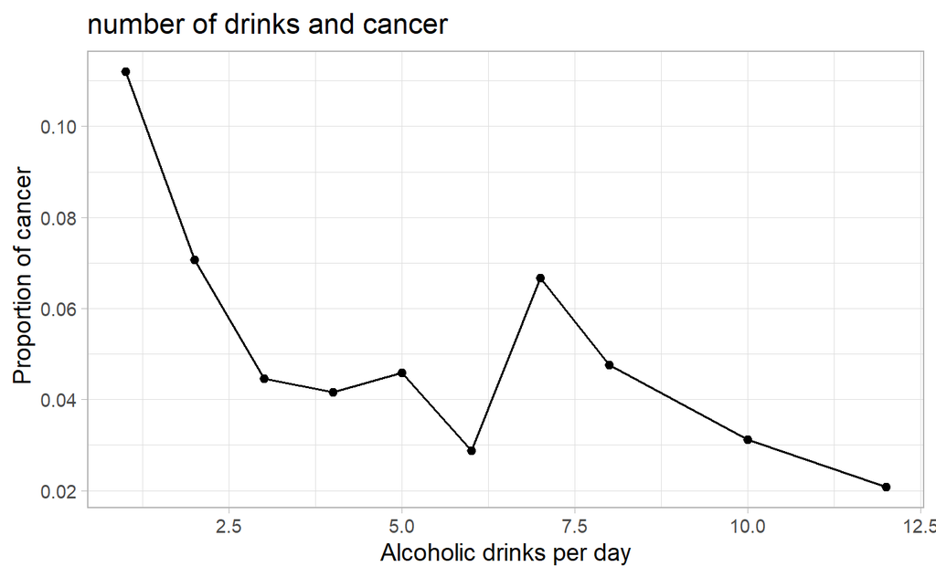

We can observe a negative relationship between cancer and alcohol, which is quite surprising. But don’t forget that NA has a double meaning in this alcohol variable, which does not necessarily give us a very realistic result.

We would like to see the effect of the coefficient and if its p-value is significant.

```
#> [1] "coefficient"
#> [1] -0.31
#> [1] "p-value"
#> [1] 0.00000255
```

We see that the coefficient has a negative effect on cancer and is very significant at its p-value close to 0. This variable will still be used in the partial model.

## 4.2.6 Cancer and smoking

We create a table including cancer and smoking variables.

**Cancer and Cigarettes per day**

| SEQN | cigarets_per_day | got_cancer |
| --- | --- | --- |
| 31154 | 15 | 0 |
| 31158 | 20 | 0 |
| 31167 | 20 | 0 |
| 31186 | 1 | 0 |
| 31210 | 10 | 0 |
| 31253 | 15 | 0 |

About this variable, it is the same as for alcohol because we only have the information on the number of cigarettes but there is no answer for the respondents who do not smoke, therefore the undetermined proportion (NA) , maybe people who didn’t respond because they don’t smoke at all, or it could just be people who didn’t respond.

We are now investigating whether people who did not respond about their cigarette consumption have a different proportion of cancer, but these results need to be taken with a lot of hindsight.

**Smoking and cancer**

| smoke | got_cancer | count | proportion |
| --- | --- | --- | --- |
| unknown | 0 | 3732 | 0.913 |
| unknown | 1 | 355 | 0.087 |
| yes | 0 | 829 | 0.934 |
| yes | 1 | 59 | 0.066 |

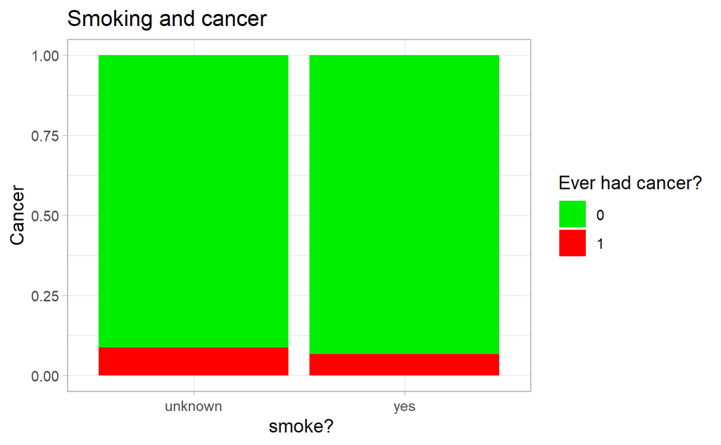

We observe that people who report smoking have a lower proportion of cancer (6.6%) than those who did not answer the question (8.7%).

Next we want to look at the number of cigarettes per day and cancer. we make a table with proportion in number of cigarettes and a scatterplot.

**Cirattes per day and cancer**

| cigarets_per_day | got_cancer | count | proportion |
| --- | --- | --- | --- |
| 1 | 0 | 28 | 0.966 |
| 1 | 1 | 1 | 0.034 |
| 2 | 0 | 8 | 0.889 |
| 2 | 1 | 1 | 0.111 |
| 3 | 0 | 30 | 0.968 |
| 3 | 1 | 1 | 0.032 |
| 4 | 0 | 29 | 1.000 |
| 5 | 0 | 45 | 0.978 |
| 5 | 1 | 1 | 0.022 |
| 6 | 0 | 25 | 0.926 |
| 6 | 1 | 2 | 0.074 |
| 7 | 0 | 22 | 0.957 |
| 7 | 1 | 1 | 0.043 |
| 8 | 0 | 24 | 0.923 |
| 8 | 1 | 2 | 0.077 |
| 9 | 0 | 3 | 1.000 |
| 10 | 0 | 158 | 0.940 |
| 10 | 1 | 10 | 0.060 |
| 11 | 0 | 1 | 1.000 |
| 12 | 0 | 20 | 0.952 |
| 12 | 1 | 1 | 0.048 |
| 13 | 0 | 2 | 1.000 |
| 14 | 0 | 2 | 1.000 |
| 15 | 0 | 55 | 0.965 |
| 15 | 1 | 2 | 0.035 |
| 16 | 0 | 7 | 1.000 |
| 17 | 0 | 4 | 1.000 |
| 18 | 0 | 8 | 0.889 |
| 18 | 1 | 1 | 0.111 |
| 19 | 0 | 2 | 1.000 |
| 20 | 0 | 223 | 0.914 |
| 20 | 1 | 21 | 0.086 |
| 22 | 0 | 2 | 1.000 |
| 24 | 0 | 1 | 1.000 |
| 25 | 0 | 15 | 0.882 |
| 25 | 1 | 2 | 0.118 |
| 26 | 0 | 2 | 1.000 |
| 27 | 0 | 1 | 1.000 |
| 30 | 0 | 56 | 0.918 |
| 30 | 1 | 5 | 0.082 |
| 35 | 0 | 4 | 1.000 |
| 40 | 0 | 42 | 0.894 |
| 40 | 1 | 5 | 0.106 |
| 45 | 0 | 1 | 1.000 |
| 50 | 0 | 6 | 0.857 |
| 50 | 1 | 1 | 0.143 |
| 60 | 0 | 3 | 0.750 |
| 60 | 1 | 1 | 0.250 |
| 90 | 1 | 1 | 1.000 |

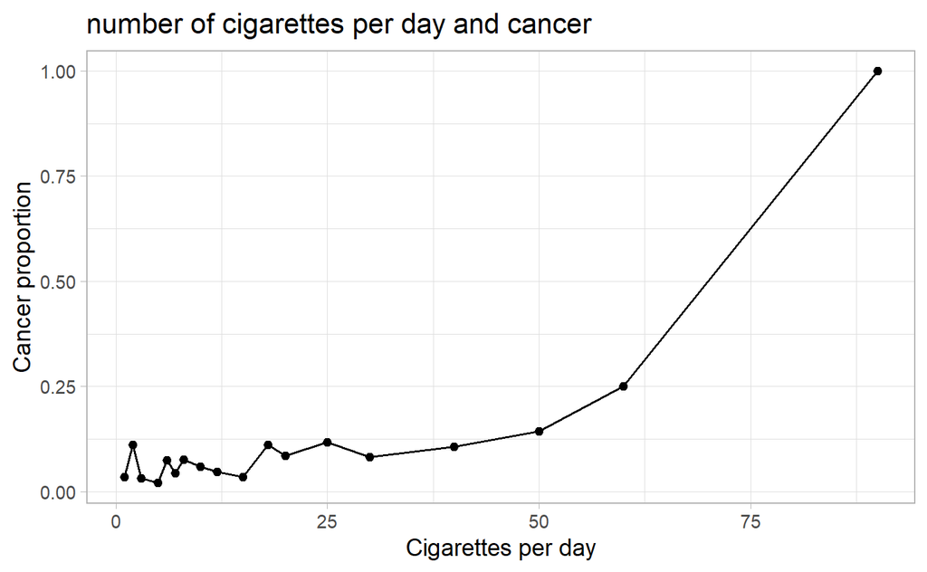

We can see a positive trend but we have to take into account that there is an outlier of 90 cigarettes smoked per day and who had cancer, so it makes it look like the relationship is strong, but this it’s not the case.

We would like to see the effect of the coefficient and if its p-value is significant.

```
#> [1] "coefficient"
#> [1] 0.0349
#> [1] "p-value"
#> [1] 0.00597
```

We can see that the coefficient has a positive effect on cancer, and the p-value is significant at a level of 0.01. This variable will be used in the partial model.